# **第四章：聚类分析**

### 4.10.4 Species Co-occurrence Network - 物种共现网络

在群落生态研究中, 物种共现网络分析变得越来越流行, 尤其是在研究物种间或者群落中的生态相互关系领域更为流行. 分析物种间关联性的基本原则主要是在生态’宏环境’或者多营养物种组合中共同存在. 基于共现网络的拓扑结构, 将物种的’社会属性组’定义为’模块’. 网络结构通常有两方面的主要特征, 一是模块性, 物种高度相关联, 物种间没有重叠; 二是嵌套性, 少量物种组合构成大量物种组合的子集 (俄罗斯套娃).

物种的作用由其自身模块中的其他物种相比的位置来定义的 (“标准化的模块内度”, 即节点与同一模块中其他节点的链接数量, 模块中每个节点连接数量的标准偏差和均值进行标准化, 以及该物种如何与其他模块中的物种相连接(模块间“连接”).

基本上, 通过邻接矩阵来构建网络(这种邻接矩阵可以是二元’有-无’矩阵类型–物种显著性共现或者不共现; 也可以是数值型的矩阵类型–物种间的连接具有加权信息).

物种间的正相关,中性相关和负相关的多种指标都可以用来用以计算包括 Spearman 相关系数,Jaccard 相似系数或者前文中的 p-value 在的邻接矩阵. 这些指标可以从物种的’有-无’二元矩阵或者丰度矩阵中计算获得. 通常应用阈值来将非零链接限制为最重要的正关联以构建**无向网络(undirected networks)**. 经常共现的物种在网络图中彼此邻近.

本章使用 picante 分析包计算共现距离, 使用 igraph 分析包进行网络处理.

```r
# 需要使用的分析包
#library(igraph)
#library(rgexf)

# --- 1 ---
# Adjacency matrix from the binary matrix of significant co-occurrences
# 由 显著性共现的二进制/二元矩阵 计算 邻接矩阵
adjm1 <- 1 - as.matrix(res.pa.dist) # 强制矩阵化 校正后的 '有-无'二元数据矩阵
diag(adjm1) <- 0 # 对角线重新赋值

# --- 2 ---
# Adjacency matrix from the "a" distance matrix
# 由 物种共现分析检验后的距离矩阵 计算 邻接矩阵 -- test.a.R test.R()
adjm2 <- 1 - as.matrix(res$p.a.dist) # 强制矩阵化
adjm2[adjm2 < 0.5] <- 0
diag(adjm2) <- 0 # 对角线重新赋值

# --- 3 ---
# Adjacency matrix from the Spearman rank correlation matrix
# 由 Spearman 秩相关性系数 计算 邻接矩阵
adjm3 <- cor(spe, # 计算相关性系数
             method = "spearman")
# 设置正相关的阈值 rho > 0.2
adjm2[adjm3 < 0.25] <- 0
adjm2[adjm3 >= 0.25] <- 1  # binary co-occurrences | 二元/二进制共现
diag(adjm3) <- 0 # 对角线重新赋值

# Species co-occurrence dissimilarities (picante, Hardy 2008)
# 物种共现相异矩阵 - picante
# https://www.rdocumentation.org/packages/picante/versions/1.7
# 整合性系统发育和生态学分析
# ?species.dist  --  Species Co-Occurrence Distances 物种共现距离
# 根据群落中物种共生的模式计算种间距离
# https://www.rdocumentation.org/packages/picante/versions/1.7/topics/species.dist
adjm4 <- species.dist(spe.pa, # 物种'有-无'二元数据矩阵
                      metric = "jaccard") # Jaccard!! - 注意距离方法!!
adjm4 <- as.matrix(adjm4) # 强制矩阵化
adjm4[adjm4 < 0.4] <- 0
adjm <- adjm4 # 选择邻接矩阵
summary(as.vector(adjm)) # 统计每列的基本信息
```

```
##    Min. 1st Qu.  Median    Mean 3rd Qu.    Max.
##  0.0000  0.0000  0.5600  0.4292  0.7059  1.0000
```

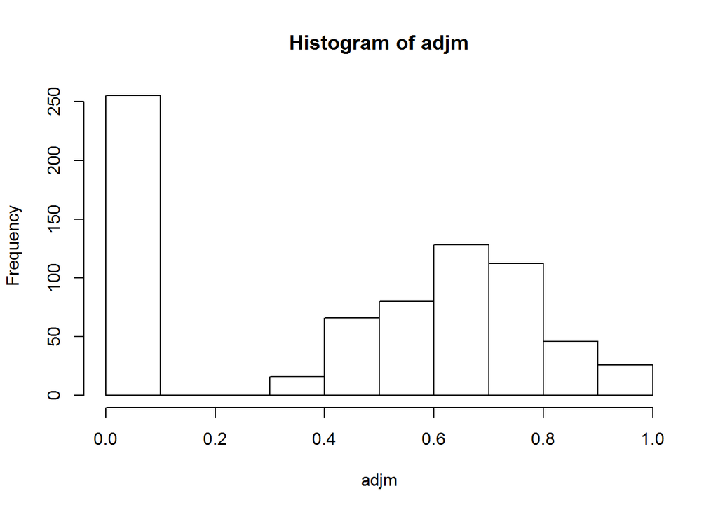

```r
# 绘制邻接值的直方图
hist(adjm)
```

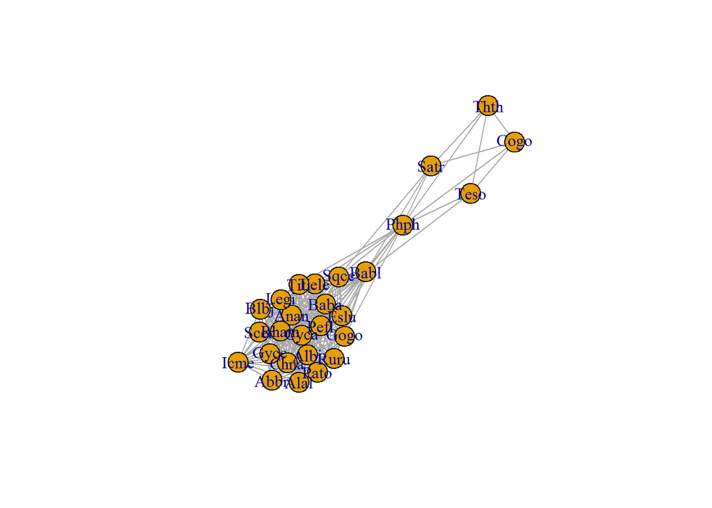

```r
# 创建图
go <- graph_from_adjacency_matrix(adjm, # 邻接矩阵
                                  weighted = TRUE,
                                  mode = "undirected")
plot(go) # 画出网络图
```

```r
# 网络结构检测: 发现 邻接矩阵在图中密集连接的子图（模块或“社区”）
# https://kateto.net/polnet2018
wc <- cluster_optimal(go) # 选取最优簇
modularity(wc) # 模块化 | 图的社区结构的模块性
```

```
## [1] 0.0968153
```

```r
membership(wc) # 成员间关系 | 处理网络社区检测的结果
```

```
## Abbr Alal Albi Anan Baba Babl Blbj Chna Cogo Cyca Eslu Gogo Gyce Icme Legi
##    1    1    1    1    1    2    1    1    3    1    2    2    1    1    1
## Lele Pato Pefl Phph Rham Ruru Satr Scer Sqce Teso Thth Titi
##    2    1    2    2    1    2    2    1    2    3    3    2
```

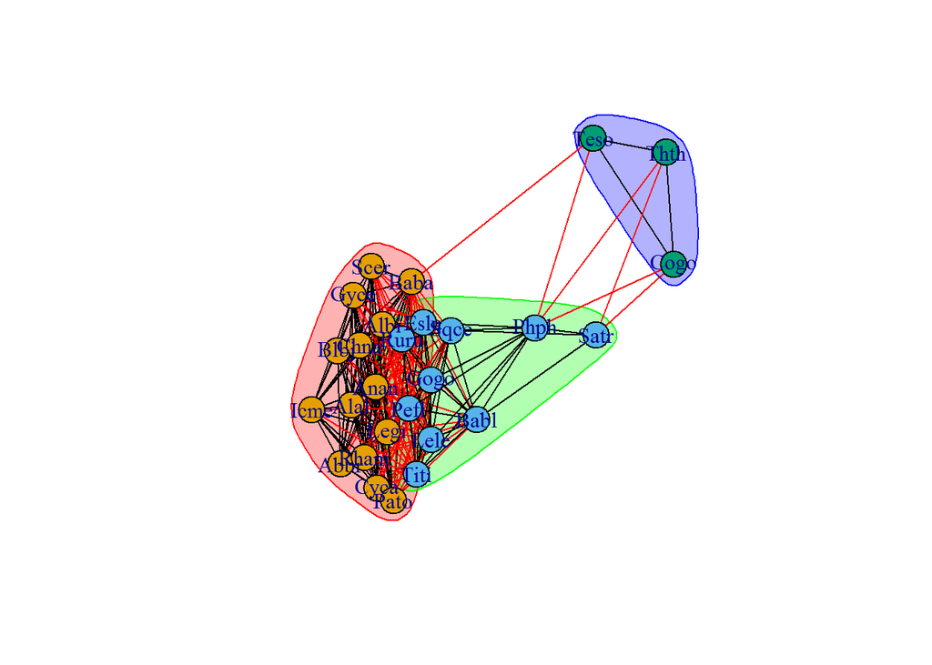

```r
plot(wc, go)
```

```r
# 输出可在 gephi 软件中查看的文件类型
gexfo <- igraph.to.gexf(go)
print(gexfo,
      file = "doubs0.gexf",
      replace = TRUE)
```

```
## GEXF graph successfully written at:
## D:\GitHub\Numerical-Ecology-with-R----Chinese\Rmdscripts\doubs0.gexf
```

## 4.11 Indicator Species - 指示性物种

### 4.11.1 简介

在应用生态学中, 搜寻多个位点处的指示性物种或者特征性物种具有格外突出的重要性, 比如可以快速评估或者预测给定位点的保守和维持性物种, 评估给定区域中活的群落的类型, 亦或是检测一些环境参量的变化. 在基础生态学中, 可以查看一系列中位点中物种的生态偏好, 就可以增加对相应物种的了解, 也可以增加对采样处栖息地生境的了解.

研究中使用的方法具有互补性, 可以使用不同的方法尝试去解释. De Cáceres 和 Legendre (2009) 提出了两种互补性质的方法以及他们相关的指标(**指示值**和**相关性指标**)

**指示者至指标** 是基于**特异性**和**保真度**两个概念提出的(特异性 – 某物种在特定类组或者位点中最高而在其他类群中无; 保真度 – 某类群在目标组中的所有位点都有存在且高). 结合高特异性值和高保真度值可以获得高指示者值.

**相关性指标** 是基于 Pearson’s 相关性系数计算而来(不同位点物种的有无).

De Cáceres 和 Legendre (2009) 一共描述了两组中共计 12 个指标. 他们认为: 指示者值在生态监测或者群落类型的确定中更有利于作为生物指示者进行评估或预测, 而相关性指标应该用于确定系列位点中给定物种的生态学偏好.

### 4.11.2 IndVal: Species Indicator Values - 物种指示值

**IndVal** 是目标类组中物种特异值和物种保真度的乘积. **特异性** 通过目标组内物种的平均丰度与其在各个组内的平均丰度相比较而定义; **保真度** 是物种存在的目标组所在位点的比例.

> **indval** 是寻找既必要又充分物种的一种方法(如果发现那个物种, 应该属于哪个类型; 如果属于那个类型, 应该找到那个物种)

可以应用多种方法定义位点组.

循环法是一种使用基于物种数据的聚类分析结果的方法. 指示者物种是这些组中最为突出的成员. 由于分类结果和指示者物种并**不是直接从独立性数据**中得来的, 因此并不能仅仅依靠统计检验来确定指示性物种.

同时还有一种在概念和统计上更有效的方法, 基于**独立型数据(比如环境变量)**对位点进行聚类. 可将通过该方法所获得的指示者物种视为真正意义上的指示者物种(类组中与其生态条件密切相关的物种).

可通过置换试验来评估指示者值的统计学显著性.

分析包 labdsv 中的 indval() 可以用于计算指示者值.

```r
# 根据与河流源头的距离,分成 4 组
dfs.D1 <- dist(data.frame(dfs = env[, 1], # 计算距离矩阵,默认方法 euclidean
               row.names = rownames(env)))
dfsD1.kmeans <- kmeans(dfs.D1, # 距离矩阵
                       centers = 4, # 分成 4 簇
                       nstart = 100) # 如果 centers 是整数,应该选取多少个随机数据集
# Cluster delimitation and numbering - 分类定界和编号
head(dfsD1.kmeans$cluster) # 查看 k-均值 聚类的簇向量
```

```
## 1 2 3 4 5 6
## 1 1 1 1 1 1
```

```r
# 编号由计算机决定
# 为了避免混淆，在 dfd1.kmeans$cluster 的基础上构造一个具有连续数字的组的向量
grps <- rep(1:4, c(8, 10, 6, 5)) # 生成重复向量, 重复次数不同
# 该地区类型学的指示性物种
# 计算群集或类型中物种的指标值（保真度和相对丰度）
# https://www.rdocumentation.org/packages/labdsv/versions/1.8-0/topics/indval
(iva <- indval(spe, # 物种数据集
               grps, # 簇向量 | 分组
               numitr = 10000) # 迭代计算概率的随机数
  ) # 直接显示全部信息
```

```
## $relfrq
##          1   2         3   4
## Cogo 0.000 0.8 0.0000000 0.0
## Satr 0.875 0.9 0.0000000 0.2
## Phph 0.875 1.0 0.3333333 0.2
## Babl 0.875 1.0 0.5000000 0.8
## Thth 0.000 0.7 0.0000000 0.2
## Teso 0.000 0.7 0.0000000 0.2
## Chna 0.000 0.3 0.6666667 1.0
## Pato 0.000 0.4 0.5000000 0.8
## Lele 0.375 0.6 0.6666667 1.0
## Sqce 0.625 0.9 1.0000000 1.0
## Baba 0.000 0.6 0.5000000 1.0
## Albi 0.000 0.4 0.5000000 1.0
## Gogo 0.375 0.7 0.8333333 1.0
## Eslu 0.500 0.5 0.6666667 1.0
## Pefl 0.375 0.4 0.5000000 1.0
## Rham 0.000 0.3 0.5000000 1.0
## Legi 0.000 0.4 0.6666667 1.0
## Scer 0.125 0.1 0.6666667 1.0
## Cyca 0.000 0.4 0.5000000 1.0
## Titi 0.500 0.5 0.5000000 1.0
## Abbr 0.000 0.1 0.5000000 1.0
## Icme 0.000 0.0 0.3333333 1.0
## Gyce 0.000 0.2 0.8333333 1.0
## Ruru 0.375 0.4 1.0000000 1.0
## Blbj 0.000 0.1 0.6666667 1.0
## Alal 0.000 0.3 1.0000000 1.0
## Anan 0.000 0.3 0.5000000 1.0
##
## $relabu
##               1          2          3          4
## Cogo 0.00000000 1.00000000 0.00000000 0.00000000
## Satr 0.52123552 0.44787645 0.00000000 0.03088803
## Phph 0.42299349 0.50759219 0.04338395 0.02603037
## Babl 0.40384615 0.42692308 0.07692308 0.09230769
## Thth 0.00000000 0.87500000 0.00000000 0.12500000
## Teso 0.00000000 0.90000000 0.00000000 0.10000000
## Chna 0.00000000 0.13636364 0.45454545 0.40909091
## Pato 0.00000000 0.38888889 0.27777778 0.33333333
```

[output cut: 64 more lines]

```
## 0.8571429 0.6857143 0.4698206 0.6936416 0.5067568 0.7346939
##
## $pval
##   Cogo   Satr   Phph   Babl   Thth   Teso   Chna   Pato   Lele   Sqce
## 0.0001 0.0190 0.0001 0.0064 0.0026 0.0021 0.0466 0.2798 0.1236 0.0404
##   Baba   Albi   Gogo   Eslu   Pefl   Rham   Legi   Scer   Cyca   Titi
## 0.0099 0.0064 0.0091 0.0020 0.0254 0.0008 0.0004 0.0037 0.0005 0.0043
##   Abbr   Icme   Gyce   Ruru   Blbj   Alal   Anan
## 0.0005 0.0002 0.0002 0.0130 0.0004 0.0078 0.0002
##
## $error
## [1] 0
##
## attr(,"class")
## [1] "indval"
```

- **注意:** 输出表中的聚类编号不一定有意义. k-均值聚类分析以数字的形式差生任意的组标签. 列标签进行了重新排序.
- 聚类分组的结果不一定按照河流的顺序, 就是为什么要对对象进行有序的组编号.
- 表中包含的信息:
1. relfrq = 每个组中物种的相对频率 = (物种存在位点的数量)/(组中位点的数量)
2. relabu = 所有组中物种的相对丰度 = (组中的总丰度)/(巨大总丰度) total abundance in group/grand total abundance
3. indval = 每个物种的指示者值
4. maxcls = 具有最高指示者值物种所在的聚类簇编号
5. indcls = 物种最高的指示者值
6. pval = 置换检验的 p-value

```r
# 多次试验校正 p-values
# 调整P值以进行多重比较 - p.adjust()
# https://www.rdocumentation.org/packages/stats/versions/3.5.3/topics/p.adjust
pval.adj <- p.adjust(iva$pval)

# 构建 显著的指示性物种表
gr <- iva$maxcls[pval.adj <= 0.05]
iv <- iva$indcls[pval.adj <= 0.05]
pv <- iva$pval[pval.adj <= 0.05]
fr <- apply(spe > 0, 2, sum)[pval.adj <= 0.05] # apply 列方向
fidg <- data.frame(
  group = gr,
  indval = iv,
  pvalue = pv,
  freq = fr
  )
fidg <- fidg[order(fidg$group, -fidg$indval), ] # 重排序 order()
head(fidg)
```

```
##      group    indval pvalue freq
## Cogo     2 0.8000000 0.0001    8
## Teso     2 0.6300000 0.0021    8
## Thth     2 0.6125000 0.0026    8
## Phph     2 0.5075922 0.0001   20
## Icme     4 0.8571429 0.0002    7
## Anan     4 0.7346939 0.0002   11
```

```r
# 输出结果文件
write.csv(fidg, "IndVal-dfs.csv")
```

- 鉴定的指示者物种可能与 4.10 章节中使用的物种组合方法的结果不一致
- 指示者物种与预定义组有关联, 而物种组合是在没有预先分类和参考环境条件下分析的.

*链接 4.12 回归树分析 MRT 相关的分析*

分析包 **indicspecies** 可用于计算各种指标物种指数, 该分析包有两个有趣的功能: 1) 汇总两个或者多个类型学的分组以寻找可能是汇集组的指示者物种 – multipatt(); 2) 通过自展分析计算指示者值–strassoc().

```r
# multipatt - Multi-Level Pattern Analysis | 研究 物种模式 与 站点组的组合 之间的关联
# https://www.rdocumentation.org/packages/indicspecies/versions/1.7.6/topics/multipatt
(iva2 <- multipatt(
  spe, # 物种数据集
  grps, # 簇分类的向量
  max.order = 2, # 位点间组合的最大顺序
  control = how(nperm = 999)) # 置换检验
  ) # 直接显示全部结果
```

```
## $call
## multipatt(x = spe, cluster = grps, max.order = 2, control = how(nperm = 999))
##
## $func
## [1] "IndVal.g"
##
## $cluster
##  [1] 1 1 1 1 1 1 1 1 2 2 2 2 2 2 2 2 2 2 3 3 3 3 3 3 4 4 4 4 4
##
## $comb
##       1 2 3 4 1+2 1+3 1+4 2+3 2+4 3+4
##  [1,] 1 0 0 0   1   1   1   0   0   0
##  [2,] 1 0 0 0   1   1   1   0   0   0
##  [3,] 1 0 0 0   1   1   1   0   0   0
##  [4,] 1 0 0 0   1   1   1   0   0   0
##  [5,] 1 0 0 0   1   1   1   0   0   0
##  [6,] 1 0 0 0   1   1   1   0   0   0
##  [7,] 1 0 0 0   1   1   1   0   0   0
##  [8,] 1 0 0 0   1   1   1   0   0   0
##  [9,] 0 1 0 0   1   0   0   1   1   0
## [10,] 0 1 0 0   1   0   0   1   1   0
## [11,] 0 1 0 0   1   0   0   1   1   0
## [12,] 0 1 0 0   1   0   0   1   1   0
## [13,] 0 1 0 0   1   0   0   1   1   0
## [14,] 0 1 0 0   1   0   0   1   1   0
## [15,] 0 1 0 0   1   0   0   1   1   0
## [16,] 0 1 0 0   1   0   0   1   1   0
## [17,] 0 1 0 0   1   0   0   1   1   0
## [18,] 0 1 0 0   1   0   0   1   1   0
## [19,] 0 0 1 0   0   1   0   1   0   1
## [20,] 0 0 1 0   0   1   0   1   0   1
## [21,] 0 0 1 0   0   1   0   1   0   1
## [22,] 0 0 1 0   0   1   0   1   0   1
## [23,] 0 0 1 0   0   1   0   1   0   1
## [24,] 0 0 1 0   0   1   0   1   0   1
## [25,] 0 0 0 1   0   0   1   0   1   1
## [26,] 0 0 0 1   0   0   1   0   1   1
## [27,] 0 0 0 1   0   0   1   0   1   1
## [28,] 0 0 0 1   0   0   1   0   1   1
## [29,] 0 0 0 1   0   0   1   0   1   1
```

[output cut: 192 more lines]

```
## Rham   0   0   1   1    10 0.8152158   0.001
## Legi   0   0   1   1    10 0.8685778   0.001
## Scer   0   0   1   1    10 0.8608910   0.001
## Cyca   0   0   0   1     4 0.8257228   0.002
## Titi   0   0   1   1    10 0.7640445   0.050
## Abbr   0   0   1   1    10 0.8439347   0.001
## Icme   0   0   0   1     4 0.9258201   0.001
## Gyce   0   0   1   1    10 0.9397430   0.001
## Ruru   0   0   1   1    10 0.8830468   0.001
## Blbj   0   0   1   1    10 0.8966570   0.001
## Alal   0   0   1   1    10 0.9638745   0.001
## Anan   0   0   0   1     4 0.8571429   0.001
##
## attr(,"class")
## [1] "multipatt"
```

- 结果包含的信息:
1. comb = 位点与所有可能组合(取决于分析中要求的顺序)的矩阵;
2. str = 相关性的强度;
3. A = IndVal 分析前提下表示 “特异性”; 其他情况无意义;
4. B = IndVal 分析前提下表示 “保真度”; 其他情况无意义;
5. sign = 最适合模型的结果, 统计结果和置换试验结果最优的组或者组合组; 不提供多重检验校正.

```r
# 多次试验校正 p-values
# 调整P值以进行多重比较 - p.adjust()
# https://www.rdocumentation.org/packages/stats/versions/3.5.3/topics/p.adjust
(pval.adj2 <- p.adjust(iva2$sign$p.value)
  ) # 直接显示全部信息
```

```
##  [1] 0.027 0.027 0.027 0.027 0.044 0.044 0.044 0.440 0.440 0.186 0.096
## [12] 0.186 0.036 0.154 0.267 0.027 0.027 0.027 0.027 0.200 0.027 0.027
## [23] 0.027 0.027 0.027 0.027 0.027
```

```r
# 汇总统计信息
# 第二次汇总统计的结果与第一次的汇总统计结果有所不同
# 具体体现: 具有高 IndVal 值的一些物种形成组合组, 代替了原先的单个组
summary(iva2, indvalcomp = TRUE)
```

```
##
##  Multilevel pattern analysis
##  ---------------------------
##
##  Association function: IndVal.g
##  Significance level (alpha): 0.05
##
##  Total number of species: 27
##  Selected number of species: 24
##  Number of species associated to 1 group: 6
##  Number of species associated to 2 groups: 18
##  Number of species associated to 3 groups: 0
##
##  List of species associated to each combination:
##
##  Group 2  #sps.  3
##          A     B  stat p.value
## Cogo 1.000 0.800 0.894   0.001 ***
## Teso 0.900 0.700 0.794   0.004 **
## Thth 0.875 0.700 0.783   0.004 **
##
##  Group 4  #sps.  3
##           A      B  stat p.value
## Icme 0.8571 1.0000 0.926   0.001 ***
## Anan 0.7347 1.0000 0.857   0.001 ***
## Cyca 0.6818 1.0000 0.826   0.002 **
##
##  Group 1+2  #sps.  3
##           A      B  stat p.value
## Phph 0.9306 0.9444 0.937   0.001 ***
## Satr 0.9691 0.8889 0.928   0.001 ***
## Babl 0.8308 0.9444 0.886   0.001 ***
##
##  Group 3+4  #sps.  15
##           A      B  stat p.value
## Alal 0.9291 1.0000 0.964   0.001 ***
## Gyce 0.9714 0.9091 0.940   0.001 ***
## Blbj 0.9827 0.8182 0.897   0.001 ***
## Ruru 0.7798 1.0000 0.883   0.001 ***
## Legi 0.9221 0.8182 0.869   0.001 ***
## Scer 0.9058 0.8182 0.861   0.001 ***
## Gogo 0.7962 0.9091 0.851   0.003 **
## Abbr 0.9793 0.7273 0.844   0.001 ***
## Chna 0.8636 0.8182 0.841   0.004 **
## Rham 0.9138 0.7273 0.815   0.001 ***
## Sqce 0.6434 1.0000 0.802   0.036 *
## Eslu 0.7727 0.8182 0.795   0.022 *
## Baba 0.8107 0.7273 0.768   0.012 *
## Titi 0.8027 0.7273 0.764   0.050 *
## Albi 0.7619 0.7273 0.744   0.031 *
## ---
## Signif. codes:  0 '***' 0.001 '**' 0.01 '*' 0.05 '.' 0.1 ' ' 1
```

```r
# 通过自举分析计算指示性物种值的置信区间
# 计算较慢
# strassoc - 计算 物种站点 - 群组 之间的关联强度
# https://www.rdocumentation.org/packages/indicspecies/versions/1.7.6/topics/strassoc
# 结果包含 3 部分:
# 指示者值 ($stat) 和 置信区间的上下限
# * 个物种, * 个分组
# 指示者值 = 0,
(iva2.boot <- strassoc(spe, #　物种数据集
                       grps, # 簇分类的向量
                       func = "IndVal.g", # 关联性分析的方法索引
                       nboot = 1000) # 自展值
  ) # 直接显示全部结果
```

```
## $stat
##               1          2         3          4
## Cogo 0.00000000 0.89442719 0.0000000 0.00000000
## Satr 0.67533775 0.63489275 0.0000000 0.07859775
## Phph 0.60837431 0.71245504 0.1202552 0.07215313
## Babl 0.59444544 0.65339351 0.1961161 0.27174649
## Thth 0.00000000 0.78262379 0.0000000 0.15811388
## Teso 0.00000000 0.79372539 0.0000000 0.14142136
## Chna 0.00000000 0.20225996 0.5504819 0.63960215
## Pato 0.00000000 0.39440532 0.3726780 0.51639778
## Lele 0.23177057 0.40863797 0.3814717 0.60013641
## Sqce 0.32097037 0.41548450 0.5096472 0.61936773
## Baba 0.00000000 0.33703447 0.3971989 0.70366585
## Albi 0.00000000 0.30860670 0.3450328 0.72374686
## Gogo 0.14569288 0.32096552 0.5170064 0.68954456
## Eslu 0.27524094 0.19462474 0.3892495 0.73854895
## Pefl 0.24045661 0.22212431 0.3635362 0.67686762
## Rham 0.00000000 0.16081688 0.3595975 0.80942721
## Legi 0.00000000 0.17654697 0.4161252 0.81384130
## Scer 0.09169554 0.05187083 0.4574577 0.76936874
## Cyca 0.00000000 0.19069252 0.3370999 0.82572282
## Titi 0.24192649 0.20033417 0.3657585 0.73151696
## Abbr 0.00000000 0.04548588 0.3713907 0.83871823
## Icme 0.00000000 0.00000000 0.2182179 0.92582010
## Gyce 0.00000000 0.07559289 0.4879500 0.82807867
## Ruru 0.21419830 0.19786792 0.5567325 0.68543457
## Blbj 0.00000000 0.04164257 0.4389513 0.83285150
## Alal 0.00000000 0.14588963 0.6498441 0.71186850
## Anan 0.00000000 0.13552619 0.3194383 0.85714286
##
## $lowerCI
##               1          2         3         4
## Cogo 0.00000000 0.70710678 0.0000000 0.0000000
## Satr 0.48735702 0.47506495 0.0000000 0.0000000
## Phph 0.41740973 0.65414599 0.0000000 0.0000000
## Babl 0.40824829 0.57896073 0.0000000 0.1114404
## Thth 0.00000000 0.54505250 0.0000000 0.0000000
## Teso 0.00000000 0.54433105 0.0000000 0.0000000
## Chna 0.00000000 0.00000000 0.2029821 0.5270463
## Pato 0.00000000 0.12718675 0.0000000 0.1825742
```

[output cut: 34 more lines]

```
## Gogo 0.3012003 0.4504426 0.6690588 0.7882270
## Eslu 0.4817517 0.3269015 0.5971068 0.8389813
## Pefl 0.4760778 0.4188539 0.6424442 0.8338223
## Rham 0.0000000 0.3388155 0.6282809 0.9419787
## Legi 0.0000000 0.3157348 0.6257862 0.9100931
## Scer 0.2950844 0.1736834 0.7108187 0.9109266
## Cyca 0.0000000 0.3558300 0.6099943 0.9508295
## Titi 0.4302634 0.3308913 0.6468623 0.8572635
## Abbr 0.0000000 0.1538968 0.6546537 0.9878292
## Icme 0.0000000 0.0000000 0.4913037 1.0000000
## Gyce 0.0000000 0.1835970 0.6210397 0.9063270
## Ruru 0.4222003 0.3586385 0.6517861 0.7852756
## Blbj 0.0000000 0.1371758 0.6546537 0.9473309
## Alal 0.0000000 0.2963189 0.6945906 0.7618118
## Anan 0.0000000 0.2844832 0.5740378 0.9636241
```

**如何解释相关的置信区间结果?**

置信区间的下限为 0, 稍微大一点的都视为不重要. 区间的范围可能会有重合, 但是不能认为最终的值就不相同; 真实的指示者值可能在交集之中, 尚无办法确定值的大小(重叠的范围无法判断大小).

### 4.11.3 Correlation-Type Indices - 相关类型指标

相关性指标用以帮助确定系列组中物种的生态学偏好. 以生态学偏好鉴定为目的, 使用相关性指标的效果要好于指示者指标, 得益于相关性指标允许检测阴性偏好.

要注意位点数据中的物种缺失相关的问题. 在不同的位点, 物种缺失的原因可能会不同, 因此不能草率地将缺失物种信息用于生物学意义的解释.

通常将植物学中代表明确生态条件的的特定组中具有高度偏好性的物种称为“诊断性”物种, 有助于野外调查中植被类型的识别.

对于二元数据类型(‘有-无’)的相关性类型指标通常称为 Pearson 相关性系数. 计算包含在两个二元(1 或者 0)向量间的相关性.

使用定量(丰度)数据时, **Pearson’s phi** 相关系数称为’点双相关系数’, 丰度向量代替’有-无’向量.

**关键还是在对结果的解读!!!!**

```r
# Phi correlation index - Phi 相关指数 - 二元变量的关联度量
# http://www.pmean.com/definitions/phi.htm
# multipatt - Multi-Level Pattern Analysis | 研究 物种模式 与 站点组的组合 之间的关联
# https://www.rdocumentation.org/packages/indicspecies/versions/1.7.6/topics/multipatt
(iva.phi <- multipatt(
  spe, #　物种数据集
  grps, # 簇分类的向量
  func = "r.g", # 关联性分析的方法索引
  max.order = 2,  # 位点间组合的最大顺序
  control = how(nperm = 999)) # 置换检验
 ) # 直接显示全部结果
```

```
## $call
## multipatt(x = spe, cluster = grps, func = "r.g", max.order = 2,
##     control = how(nperm = 999))
##
## $func
## [1] "r.g"
##
## $cluster
##  [1] 1 1 1 1 1 1 1 1 2 2 2 2 2 2 2 2 2 2 3 3 3 3 3 3 4 4 4 4 4
##
## $comb
##       1 2 3 4 1+2 1+3 1+4 2+3 2+4 3+4
##  [1,] 1 0 0 0   1   1   1   0   0   0
##  [2,] 1 0 0 0   1   1   1   0   0   0
##  [3,] 1 0 0 0   1   1   1   0   0   0
##  [4,] 1 0 0 0   1   1   1   0   0   0
##  [5,] 1 0 0 0   1   1   1   0   0   0
##  [6,] 1 0 0 0   1   1   1   0   0   0
##  [7,] 1 0 0 0   1   1   1   0   0   0
##  [8,] 1 0 0 0   1   1   1   0   0   0
##  [9,] 0 1 0 0   1   0   0   1   1   0
## [10,] 0 1 0 0   1   0   0   1   1   0
## [11,] 0 1 0 0   1   0   0   1   1   0
## [12,] 0 1 0 0   1   0   0   1   1   0
## [13,] 0 1 0 0   1   0   0   1   1   0
## [14,] 0 1 0 0   1   0   0   1   1   0
## [15,] 0 1 0 0   1   0   0   1   1   0
## [16,] 0 1 0 0   1   0   0   1   1   0
## [17,] 0 1 0 0   1   0   0   1   1   0
## [18,] 0 1 0 0   1   0   0   1   1   0
## [19,] 0 0 1 0   0   1   0   1   0   1
## [20,] 0 0 1 0   0   1   0   1   0   1
## [21,] 0 0 1 0   0   1   0   1   0   1
## [22,] 0 0 1 0   0   1   0   1   0   1
## [23,] 0 0 1 0   0   1   0   1   0   1
## [24,] 0 0 1 0   0   1   0   1   0   1
## [25,] 0 0 0 1   0   0   1   0   1   1
## [26,] 0 0 0 1   0   0   1   0   1   1
## [27,] 0 0 0 1   0   0   1   0   1   1
## [28,] 0 0 0 1   0   0   1   0   1   1
```

[output cut: 83 more lines]

```
## Rham   0   0   0   1     4 0.7587557   0.002
## Legi   0   0   0   1     4 0.7966650   0.002
## Scer   0   0   1   1    10 0.6003028   0.008
## Cyca   0   0   0   1     4 0.7356829   0.002
## Titi   0   0   0   1     4 0.6696361   0.002
## Abbr   0   0   0   1     4 0.7564314   0.003
## Icme   0   0   0   1     4 0.8285293   0.002
## Gyce   0   0   0   1     4 0.8588143   0.002
## Ruru   0   0   1   1    10 0.6513912   0.003
## Blbj   0   0   0   1     4 0.7899029   0.002
## Alal   0   0   1   1    10 0.9195176   0.001
## Anan   0   0   0   1     4 0.8546083   0.002
##
## attr(,"class")
## [1] "multipatt"
```

```r
# 统计每列的基本信息
# 结果与 IndVal 分析的相似 | 使用两种方法揭示了某些物种和选定组之间的强相关性
# 统计检验中显示了最高的"正 Pearson's phi 相关系数值"
summary(iva.phi)
```

```
##
##  Multilevel pattern analysis
##  ---------------------------
##
##  Association function: r.g
##  Significance level (alpha): 0.05
##
##  Total number of species: 27
##  Selected number of species: 23
##  Number of species associated to 1 group: 14
##  Number of species associated to 2 groups: 9
##  Number of species associated to 3 groups: 0
##
##  List of species associated to each combination:
##
##  Group 2  #sps.  3
##       stat p.value
## Cogo 0.785   0.001 ***
## Teso 0.658   0.001 ***
## Thth 0.650   0.002 **
##
##  Group 4  #sps.  11
##       stat p.value
## Gyce 0.859   0.002 **
## Anan 0.855   0.002 **
## Icme 0.829   0.002 **
## Legi 0.797   0.002 **
## Blbj 0.790   0.002 **
## Rham 0.759   0.002 **
## Abbr 0.756   0.003 **
## Cyca 0.736   0.002 **
## Eslu 0.705   0.002 **
## Titi 0.670   0.002 **
## Sqce 0.486   0.047 *
##
##  Group 1+2  #sps.  3
##       stat p.value
## Phph 0.855   0.001 ***
## Babl 0.778   0.001 ***
## Satr 0.775   0.001 ***
##
##  Group 3+4  #sps.  6
##       stat p.value
## Alal 0.920   0.001 ***
## Gogo 0.690   0.001 ***
## Ruru 0.651   0.003 **
## Chna 0.611   0.006 **
## Scer 0.600   0.008 **
## Baba 0.583   0.011 *
## ---
## Signif. codes:  0 '***' 0.001 '**' 0.01 '*' 0.05 '.' 0.1 ' ' 1
```

```r
round(iva.phi$str, 3) # 保留三位小数
```

```
##           1      2      3      4    1+2    1+3    1+4    2+3    2+4    3+4
## Cogo -0.262  0.785 -0.262 -0.262  0.453 -0.453 -0.453  0.453  0.453 -0.453
## Satr  0.518  0.378 -0.477 -0.418  0.775  0.035  0.086 -0.086 -0.035 -0.775
## Phph  0.397  0.591 -0.474 -0.513  0.855 -0.067 -0.101  0.101  0.067 -0.855
## Babl  0.418  0.481 -0.470 -0.428  0.778 -0.045 -0.009  0.009  0.045 -0.778
## Thth -0.260  0.650 -0.260 -0.130  0.338 -0.450 -0.338  0.338  0.450 -0.338
## Teso -0.253  0.658 -0.253 -0.152  0.351 -0.439 -0.351  0.351  0.439 -0.351
## Chna -0.485 -0.220  0.397  0.309 -0.611 -0.076 -0.153  0.153  0.076  0.611
## Pato -0.433  0.241  0.048  0.144 -0.167 -0.333 -0.250  0.250  0.333  0.167
## Lele -0.267  0.071 -0.079  0.276 -0.170 -0.300  0.007 -0.007  0.300  0.170
## Sqce -0.310 -0.212  0.035  0.486 -0.452 -0.238  0.153 -0.153  0.238  0.452
## Baba -0.541 -0.131  0.142  0.531 -0.583 -0.346 -0.009  0.009  0.346  0.583
## Albi -0.420 -0.020 -0.020  0.460 -0.381 -0.381  0.035 -0.035  0.381  0.381
## Gogo -0.520 -0.277  0.190  0.607 -0.690 -0.286  0.075 -0.075  0.286  0.690
## Eslu -0.235 -0.416 -0.054  0.705 -0.564 -0.251  0.407 -0.407  0.251  0.564
## Pefl -0.196 -0.259  0.029  0.425 -0.393 -0.144  0.199 -0.199  0.144  0.393
## Rham -0.468 -0.307  0.016  0.759 -0.671 -0.391  0.252 -0.252  0.391  0.671
## Legi -0.483 -0.332  0.019  0.797 -0.706 -0.402  0.272 -0.272  0.402  0.706
## Scer -0.312 -0.381  0.109  0.584 -0.600 -0.176  0.235 -0.235  0.176  0.600
## Cyca -0.426 -0.271 -0.039  0.736 -0.604 -0.402  0.268 -0.268  0.402  0.604
## Titi -0.312 -0.399  0.041  0.670 -0.616 -0.235  0.310 -0.310  0.235  0.616
## Abbr -0.417 -0.383  0.043  0.756 -0.692 -0.324  0.294 -0.294  0.324  0.692
## Icme -0.341 -0.341 -0.146  0.829 -0.591 -0.422  0.422 -0.422  0.422  0.591
## Gyce -0.493 -0.436  0.070  0.859 -0.805 -0.366  0.317 -0.317  0.366  0.805
## Ruru -0.343 -0.409  0.161  0.591 -0.651 -0.158  0.215 -0.215  0.158  0.651
## Blbj -0.445 -0.414  0.069  0.790 -0.744 -0.325  0.299 -0.299  0.325  0.744
## Alal -0.619 -0.443  0.426  0.635 -0.920 -0.167  0.014 -0.014  0.167  0.920
## Anan -0.441 -0.333 -0.081  0.855 -0.670 -0.452  0.358 -0.358  0.452  0.670
```

```r
(iva.phi.boot <- strassoc(spe, #　物种数据集
                          grps, # 簇分类的向量
                          func = "r.g", # 关联性分析的方法索引
                          nboot = 1000) # 自展值
  ) # 直接显示全部结果
```

```
## $stat
##               1           2           3          4
## Cogo -0.2617120  0.78513588 -0.26171196 -0.2617120
## Satr  0.5177167  0.37769367 -0.47718370 -0.4182266
## Phph  0.3966125  0.59056721 -0.47369706 -0.5134826
## Babl  0.4179099  0.48059635 -0.47014860 -0.4283576
## Thth -0.2598279  0.64956980 -0.25982792 -0.1299140
## Teso -0.2531848  0.65828059 -0.25318484 -0.1519109
## Chna -0.4849534 -0.22043336  0.39678004  0.3086067
## Pato -0.4330127  0.24056261  0.04811252  0.1443376
## Lele -0.2670970  0.07082765 -0.07936110  0.2756305
## Sqce -0.3097752 -0.21166456  0.03542883  0.4860109
## Baba -0.5412588 -0.13137350  0.14188338  0.5307489
## Albi -0.4202522 -0.02001201 -0.02001201  0.4602762
## Gogo -0.5202560 -0.27662391  0.19033755  0.6065423
## Eslu -0.2350848 -0.41591932 -0.05425035  0.7052545
## Pefl -0.1955708 -0.25851314  0.02922322  0.4248607
## Rham -0.4681684 -0.30673102  0.01614374  0.7587557
## Legi -0.4830174 -0.33246651  0.01881886  0.7966650
## Scer -0.3121180 -0.38105199  0.10914554  0.5840244
## Cyca -0.4259217 -0.27104108 -0.03872015  0.7356829
## Titi -0.3122350 -0.39863970  0.04123859  0.6696361
## Abbr -0.4170439 -0.38252994  0.04314247  0.7564314
## Icme -0.3411591 -0.34115913 -0.14621105  0.8285293
## Gyce -0.4927623 -0.43644659  0.07039461  0.8588143
## Ruru -0.3431875 -0.40897426  0.16117753  0.5909843
## Blbj -0.4451244 -0.41424874  0.06947029  0.7899029
## Alal -0.6186677 -0.44309983  0.42637908  0.6353884
## Anan -0.4407979 -0.33284742 -0.08096289  0.8546083
##
## $lowerCI
##                1          2          3           4
## Cogo -0.31108551  0.6199856 -0.3110855 -0.31108551
## Satr  0.23346536  0.1177669 -0.5750183 -0.51228874
## Phph  0.07698353  0.4615825 -0.5859232 -0.62850406
## Babl  0.06849649  0.2595722 -0.6158186 -0.58764291
## Thth -0.36303929  0.4127179 -0.3630393 -0.27907279
## Teso -0.34035165  0.4538196 -0.3403516 -0.27622771
## Chna -0.62464216 -0.4413742 -0.1702819  0.06851887
## Pato -0.58905817 -0.1951800 -0.3402944 -0.19397544
```

[output cut: 34 more lines]

```
## Gogo -0.34556722 -0.04572261  0.5893701  0.8649459
## Eslu  0.08548360 -0.25451331  0.3220088  0.8907289
## Pefl  0.17429496  0.05653633  0.5107821  0.7926527
## Rham -0.35856588 -0.11564852  0.4059990  0.9301745
## Legi -0.38118499 -0.19259684  0.3537450  0.9331875
## Scer -0.06892162 -0.25363847  0.5599483  0.8339904
## Cyca -0.33464918 -0.09264026  0.3448143  0.9341014
## Titi -0.05672835 -0.21619444  0.5240338  0.8806933
## Abbr -0.32444284 -0.27824293  0.4444738  0.9649702
## Icme -0.27990991 -0.27990991  0.1417051  0.9776953
## Gyce -0.40882833 -0.33872089  0.3213820  0.9596437
## Ruru  0.03279021 -0.15583284  0.5177648  0.7972840
## Blbj -0.35028013 -0.31116618  0.4329905  0.9542841
## Alal -0.54955748 -0.29423771  0.5680491  0.7737293
## Anan -0.34731560 -0.20158013  0.2181105  0.9587621
```

## 4.12 Multivariate Regression Trees (MRT): Constrained Clustering - 多元回归树 (MRT): 约束性聚类

### 4.12.1 简介

多元回归树是一元回归树的扩展版本, 在定量或者类别解释性变量控制下可对定量响应变量进行递归分割. 有时也成这种方法为约束性或者监督性**聚类**. 分析结果以**树**的形式呈现, 其中, 叶子(末端位点组)是依据组内平方和最小的原先选取的位点组合, 但是每个连续性分区通过一个阈值或者可解释性变量来决定. 在诸多候选的方案中, 依据组的组成和叶端数量, 保留预测效能最好的方案. **多元回归树分析的选择依据是–预测效能; 第六章中介绍的诸多约束性排序方法则是依据–可解释性效能进行方案的选择.** 介于使用的是预测效能, 因此在环境管理中经常使用多元回归树模型(MRT).

MRT是一种健壮且多面型的分析方法, 可以适应多种场景, 某些数值缺失, 解释性变量与响应变量呈现非线性关系, 或者解释性变量之间存在交互项(? 多重共线?)

### 4.12.2 计算原理

MRT (多元回归树方法)包括两部分的分析过程: **1)** 对数据进行约束性分区; **2)** 交叉验证结果.

#### 4.12.2.1 Constrained Partitioning of the Data - 约束性的数据分区

-1. 对于每个解释性变量, 将位点间所有可能的分区换成两组. **1)** 定量变量: 依据变量的有序值对位点进行排序, 在第一个对象,第二个对象之后反复拆分; **2)** 分类变量: 将对象分成两个组, 并筛选所有可能的组合. 在所有的情况下, 计算响应数据的组内平方距离和与组均值(组内SS)的和. 保留和最小的分组方案, 以及解释变量的标识与值, 产生分区的分类变量的级别.

-2. 对上述保留的方案中的两个亚组内重复相同的操作, 在每个分组中保留最优的分区方案以及相应的解释变量和阈值;

-3. 在所有分区内继续上述操作, 直至所有对象形成各自的分组或者直到获得每组对象的预选最小数值. 选择适合研究的树的大小. 使用交叉验证识别最佳的预测树.

-4. 除了叶子的数量和组成外, 相对误差(relative error, RE)也是树的一个重要特征, 所有叶子的组内平方和(with-in group SS)的和 除以 原始数据的平方和(SS). (相对误差就是不能通过回归树解释的方差的比例). 在没有进行交叉验证( cross-validated)时, 连续性的分区分析将保留相对误差(RE)最小的解决方案, 等同于保留了 R方(决定系数) 最大化的解决方案. **然而,** 这将是解释性的方法而非预测性的方法. **相对误差(RE)方法对新数据预测准确度的估计过于乐观, 可以从交叉验证相对误差(CVRE)的分析中获取更优的预测精度.**

#### 4.12.2.2 Cross-Validation of the Partitions and Pruning of the Tree - 分区块的交叉验证与树形的修剪

应该在哪一层剪去一颗树, 从而保留最敏感的分区结果. 为了以预测为导向的方式回答这个问题, 使用对象的子集(用作训练集)构造树, 然后将其余的对象(测试集或者验证集)分配给所构造成树的对象来验证结果.

预测误差的度量方式是交叉验证相对误差(CVRE), 也可以将其定义为一种比值(即: 通过树无法解释的方差**除以**响应变量总方差). 因此, 在每个分区处理之后, 分子都会有所变动. CVRE 趋于 0 表示越是完美的预测结果, 趋于 1 则表示预测效果越差.

#### 4.12.2.3 MRT Procedure - 多元回归树方法的分析过程

MRT 分析过程主要包括两部分, 下面的内容将其整合在一起进行介绍:

- 1. 随机分割成 k 组; 默认使用 10;
- 2. 选择一组通过约束性分区构建树, 基于组内最小平方和(SS)进行决策;
- 3. 重复上述步骤 k-1 次, 依次省略每个测试;
- 4. 在 k 个解决方案中, 对于这些解决方案中的每个可能分区大小(组数), 重新分配测试集. 计算 k 个解决方案的所有分区大小; 包括分区水平和所有 k 个解决方案水平的计算.
- 5. 修剪树: 保留 CVRE 最小化分区的大小. 另一种替代方案是: 最小 CVRE 值 **加** CVRE 值的一个标准误差 **作为新的 CVRE 值** – “1 SE 准则”.
- 6. 为获得这个过程的误差估计, 将对象对随机化分配给 k 个组, 并且重复多次(100 或 500)
- 7. 最终树中保留了所有置换分析中最小的 CVRE 值, 或者最符合“1 SE 准则”的一棵树.
- 8. 在 mvpart() 中, 当参数 minauto = TRUE时, 一组中最小可能的对象数等于ceiling(log2(n)). 设置 minauto = FALSE 允许分区继续进行, 直到数据集完全拆分为单独的观察结果.

在多元回归树分析(MRT)中, 平方和(SS)是使用 Euclidean 空间距离计算而得. 为能够解释数据的特殊特征, 需要对数据进行预处理(章节 2.2.4 中有相关的内容介绍). 对于使用不同物理单元进行环境描述的响应数据, 在进行 MRT 分析之前需要对其进行标准化.

### 4.12.3 Application Using Packages mvpart and MVPARTwrap - 应用 mvpart 和 MVPARTwrap 分析包进行分析

**注意仔细观察代码和输出的结果**

```r
# Testing mvpart | Multivariate partitioning 多元变量分区 | Multivariate regression trees
# https://bookdown.org/forestgeoguest/mpart/mvpart.html
# https://cran.r-project.org/src/contrib/Archive/mvpart/
# 递归分区与回归树
spe.ch.mvpart <- mvpart(
    data.matrix(spe.norm) ~ ., # 符号表达式 - 映射关系 y ~ model | 响应数据集
    env, # 环境因子数据集
    margin = 0.08, # 边距设置
    cp = 0, # prune.rpart() 成本复杂度修剪 - 通过复杂度剪切掉最不重要的分区 - 复杂度参数
    xv = "pick", # 选择交叉验证的方法选择树形
    xval = nrow(spe), # 交叉验证的数量 - 交叉验证的向量
    xvmult = 100 # 多重交叉验证的次数
  )
```

```
## X-Val rep : 1  2  3  4  5  6  7  8  9  10  11  12  13  14  15  16  17  18  19  20  21  22  23  24  25  26  27  28  29  30  31  32  33  34  35  36  37  38  39  40  41  42  43  44  45  46  47  48  49  50  51  52  53  54  55  56  57  58  59  60  61  62  63  64  65  66  67  68  69  70  71  72  73  74…
## Minimum tree sizes
## tabmins
##  2  3  4  6  7  8  9 10 11
##  6 10  7  4 18 21  6 24  4
```

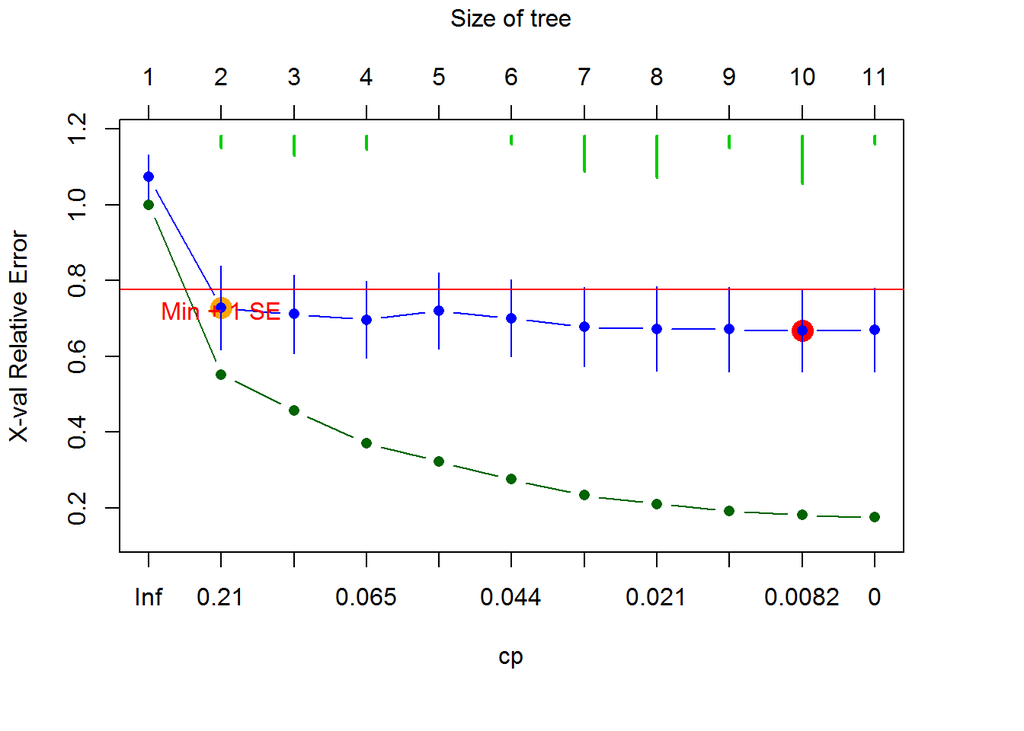

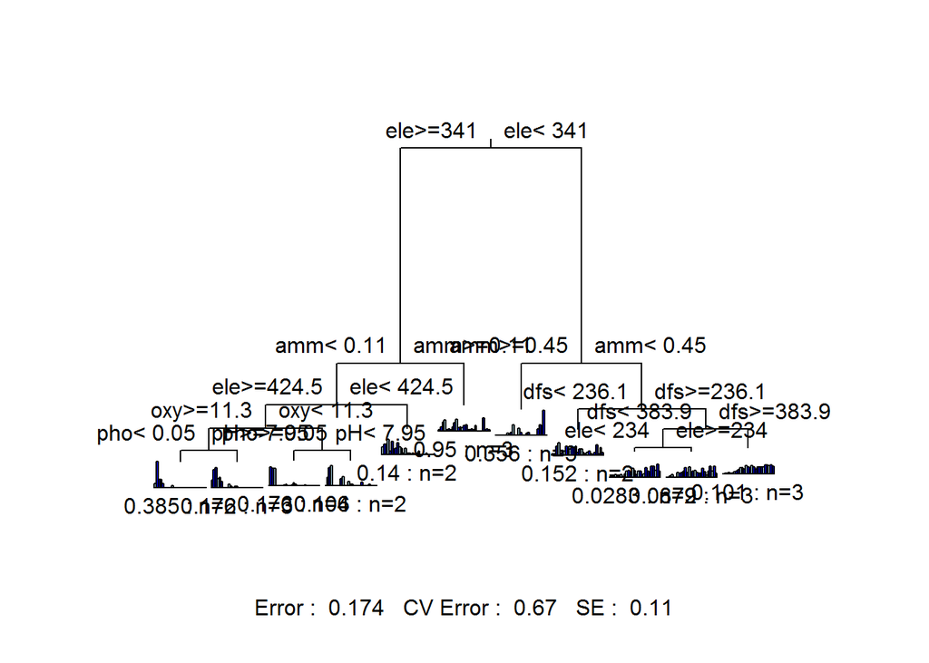

```r
summary(spe.ch.mvpart) # 统计每列的基本信息
```

```
## Call:
## mvpart(form = data.matrix(spe.norm) ~ ., data = env, xv = "pick",
##     xval = nrow(spe), xvmult = 100, margin = 0.08, cp = 0)
##   n= 29
##
##             CP nsplit rel error    xerror       xstd
## 1  0.448208890      0 1.0000000 1.0741733 0.05827392
## 2  0.095060506      1 0.5517911 0.7281468 0.11047632
## 3  0.086261428      2 0.4567306 0.7114708 0.10360460
## 4  0.048899080      3 0.3704692 0.6963984 0.10152463
## 5  0.046819347      4 0.3215701 0.7197328 0.10096664
## 6  0.042207723      5 0.2747507 0.7003012 0.10183496
## 7  0.022417406      6 0.2325430 0.6771980 0.10445748
## 8  0.019173764      7 0.2101256 0.6721464 0.11182577
## 9  0.009623512      8 0.1909519 0.6707695 0.11135083
## 10 0.006943775      9 0.1813283 0.6675629 0.10942599
## 11 0.000000000     10 0.1743846 0.6702478 0.11015005
##
## Node number 1: 29 observations,    complexity param=0.4482089
##   Means=0.05571,0.2515,0.27,0.2729,0.05579,0.06116,0.04772,0.07049,0.1295,0.1958,0.1094,0.06915,0.1578,0.1098,0.09459,0.07749,0.07079,0.05359,0.057,0.1183,0.05701,0.03674,0.09898,0.1923,0.07156,0.1933,0.06187, Summed MSE=0.5256098
##   left son=2 (16 obs) right son=3 (13 obs)
##   Primary splits:
##       ele < 341    to the right, improve=0.4482089, (0 missing)
##       dfs < 204.75 to the left,  improve=0.4482089, (0 missing)
##       dis < 24.65  to the left,  improve=0.4482089, (0 missing)
##       amm < 0.06   to the left,  improve=0.3825997, (0 missing)
##       oxy < 9.55   to the right, improve=0.3619088, (0 missing)
##
## Node number 2: 16 observations,    complexity param=0.08626143
##   Means=0.09453,0.4461,0.441,0.4128,0.09132,0.09554,0.005803,0.04497,0.1255,0.17,0.04618,0.02865,0.07062,0.06948,0.06199,0.005803,0.01124,0.01141,0.01124,0.06578,0,0,0,0.08812,0,0.01161,0.005803, Summed MSE=0.3337866
##   left son=4 (13 obs) right son=5 (3 obs)
##   Primary splits:
##       amm < 0.11   to the left,  improve=0.2462006, (0 missing)
##       bod < 4.05   to the left,  improve=0.2423770, (0 missing)
##       oxy < 10.25  to the right, improve=0.2423770, (0 missing)
##       pho < 0.15   to the left,  improve=0.1819782, (0 missing)
##       nit < 0.51   to the left,  improve=0.1785430, (0 missing)
##
## Node number 3: 13 observations,    complexity param=0.09506051
##   Means=0.007934,0.01205,0.05962,0.1008,0.01205,0.01885,0.09931,0.1019,0.1345,0.2275,0.1871,0.119,0.2651,0.1593,0.1347,0.1657,0.1441,0.1055,0.1133,0.1829,0.1272,0.08196,0.2208,0.3205,0.1596,0.4168,0.1309, Summed MSE=0.2361686
```

[output cut: 95 more lines]

```
##
## Node number 33: 3 observations
##   Means=0.2391,0.5469,0.6088,0.2718,0.3113,0.1772,0,0,0,0.09458,0.03269,0,0.03269,0.03269,0,0,0,0,0,0,0,0,0,0,0,0,0, Summed MSE=0.05873831
##
## Node number 34: 4 observations
##   Means=0,0.5857,0.5485,0.5435,0,0,0,0,0.03032,0.05881,0,0,0.02849,0.08566,0.05698,0,0,0,0,0.02849,0,0,0,0,0,0,0, Summed MSE=0.044106
##
## Node number 35: 2 observations
##   Means=0,0.2661,0.5606,0.6236,0,0,0,0,0.2173,0.2803,0,0,0.1401,0.06299,0.06299,0,0,0,0,0.126,0,0,0,0.06299,0,0,0, Summed MSE=0.05287092
##
## Node number 60: 2 observations
##   Means=0,0,0,0.07981,0,0,0.07981,0.03319,0.113,0.1928,0.226,0.07981,0.2726,0.226,0.07981,0.1928,0.1928,0.07981,0.113,0.3058,0.1928,0.113,0.3524,0.3524,0.226,0.3991,0.1928, Summed MSE=0.01414373
##
## Node number 61: 3 observations
##   Means=0,0,0.04899,0.09476,0,0,0.1591,0.1387,0.1591,0.2048,0.2978,0.1438,0.3213,0.1826,0.203,0.208,0.1591,0.1387,0.1336,0.2774,0.1776,0.06429,0.203,0.3467,0.203,0.3467,0.1387, Summed MSE=0.02929994
```

```r
printcp(spe.ch.mvpart) # 打印结果对象 - 复杂度表格
```

```
## mvpart(form = data.matrix(spe.norm) ~ ., data = env, xv = "pick",
##     xval = nrow(spe), xvmult = 100, margin = 0.08, cp = 0)
##
## Variables actually used in tree construction:
## [1] amm dfs ele oxy pH  pho
##
## Root node error: 15.243/29 = 0.52561
##
## n= 29
##
##           CP nsplit rel error  xerror     xstd
## 1  0.4482089      0   1.00000 1.07417 0.058274
## 2  0.0950605      1   0.55179 0.72815 0.110476
## 3  0.0862614      2   0.45673 0.71147 0.103605
## 4  0.0488991      3   0.37047 0.69640 0.101525
## 5  0.0468193      4   0.32157 0.71973 0.100967
## 6  0.0422077      5   0.27475 0.70030 0.101835
## 7  0.0224174      6   0.23254 0.67720 0.104457
## 8  0.0191738      7   0.21013 0.67215 0.111826
## 9  0.0096235      8   0.19095 0.67077 0.111351
## 10 0.0069438      9   0.18133 0.66756 0.109426
## 11 0.0000000     10   0.17438 0.67025 0.110150
```

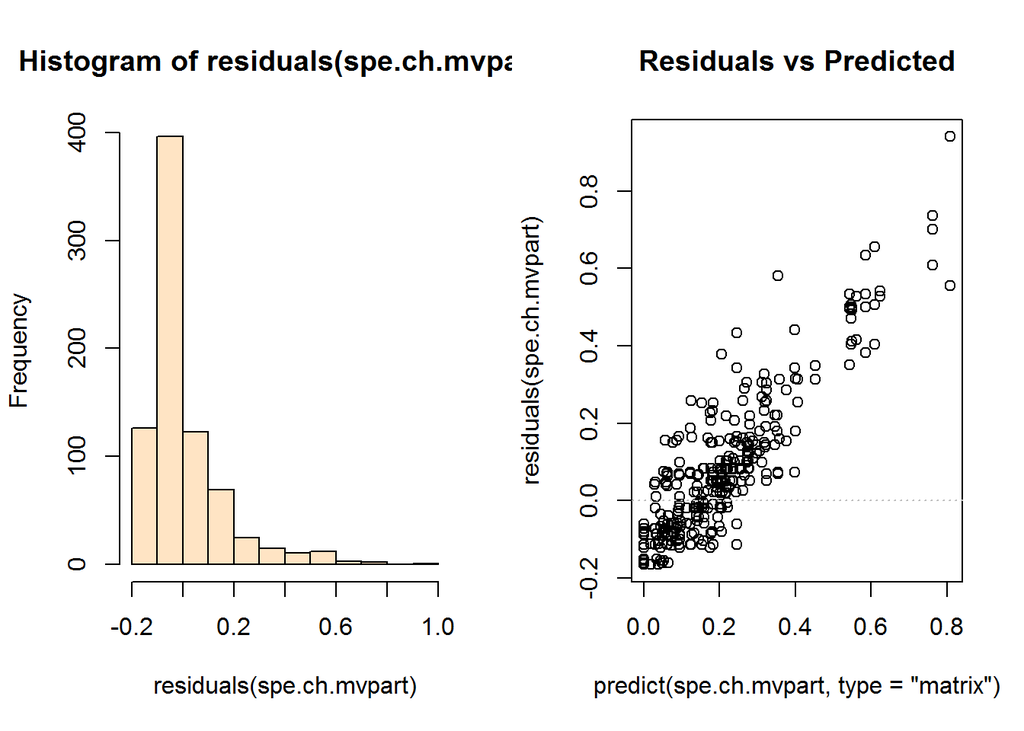

```r
# Residuals of MRT - 多元回归树分析的残差
par(mfrow = c(1, 2))
# 残差分析 - residual analysis : 通过残差所提供的信息,分析出数据的可靠性,周期性或其它干扰
# 残差: 指观测值与预测值（拟合值）之间的差，即是实际观察值与回归估计值的差
# 异常值检验、方差齐性检验、误差的正态性检验、相关性检验以及相伴随的方差稳定化变换，正态化变换等修正方法
hist(residuals(spe.ch.mvpart), # 提取模型残差
     col = "bisque")
plot(predict(spe.ch.mvpart, # 使用拟合模型进行预测
             type = "matrix"), # 返回的形式 | 其一 "vector", "prob", "class", "matrix"
     residuals(spe.ch.mvpart),
     main = "Residuals vs Predicted"
     )
abline(h = 0, lty = 3, col = "grey")
```

```r
# Group composition - 群体 成分
head(spe.ch.mvpart$where) # 查看部分数据
```

```
##  1  2  3  4  5  6
##  6  9  9  9 12 10
```

```r
# Group identity # 群体 一致性
(groups.mrt <- levels(as.factor(spe.ch.mvpart$where)) # 查看因子水平
  )  # 直接显示全部结果
```

```
##  [1] "6"  "7"  "9"  "10" "11" "12" "14" "16" "19" "20" "21"
```

```r
# Fish composition of first leaf - 第一叶 鱼类组分
spe.norm[which(spe.ch.mvpart$where == groups.mrt[1]), ]
```

```
##        Cogo      Satr     Phph     Babl     Thth Teso Chna Pato Lele
## 1  0.000000 1.0000000 0.000000 0.000000 0.000000    0    0    0    0
## 12 0.246183 0.6154575 0.492366 0.492366 0.246183    0    0    0    0
##         Sqce Baba Albi Gogo Eslu Pefl Rham Legi Scer Cyca Titi Abbr Icme
## 1  0.0000000    0    0    0    0    0    0    0    0    0    0    0    0
## 12 0.1230915    0    0    0    0    0    0    0    0    0    0    0    0
##    Gyce Ruru Blbj Alal Anan
## 1     0    0    0    0    0
## 12    0    0    0    0    0
```

```r
# Environmental variables of first leaf - 第一叶 环境变量
env[which(spe.ch.mvpart$where == groups.mrt[1]), ]
```

```
##      dfs ele  slo   dis  pH har  pho nit amm  oxy bod
## 1    0.3 934 48.0  0.84 7.9  45 0.01 0.2   0 12.2 2.7
## 12 132.4 477  1.6 20.00 7.9  86 0.04 0.5   0 12.2 3.0
```

- 叶子: 样方数量和 RE (相对误差)

```r
# 可视化 所有叶 的鱼类组分 -- 使用饼图
leaf.sum <- matrix(0, length(groups.mrt), ncol(spe))
colnames(leaf.sum) <- colnames(spe)
for (i in 1:length(groups.mrt)) {
  leaf.sum[i, ] <-
    apply(spe.norm[which(spe.ch.mvpart$where == groups.mrt[i]), ],
          2, sum) # 按照列方向进行处理
  }
head(leaf.sum) # 查看部分数据
```

```
##            Cogo      Satr      Phph      Babl       Thth      Teso
## [1,] 0.24618298 1.6154575 0.4923660 0.4923660 0.24618298 0.0000000
## [2,] 0.71722587 1.6407672 1.8264625 0.8152839 0.93396211 0.5315305
## [3,] 0.00000000 2.3428275 2.1940989 2.1739453 0.00000000 0.0000000
## [4,] 0.00000000 0.5322678 1.1211660 1.2471542 0.00000000 0.0000000
## [5,] 0.45629392 0.6374048 0.6374048 0.9055546 0.18814417 0.8114825
## [6,] 0.09284767 0.3682695 0.7839270 0.9699900 0.09284767 0.1856953
##            Chna      Pato      Lele      Sqce       Baba       Albi
## [1,] 0.00000000 0.0000000 0.0000000 0.1230915 0.00000000 0.00000000
## [2,] 0.00000000 0.0000000 0.0000000 0.2837534 0.09805807 0.00000000
## [3,] 0.00000000 0.0000000 0.1212678 0.2352284 0.00000000 0.00000000
## [4,] 0.00000000 0.0000000 0.4345949 0.5605830 0.00000000 0.00000000
## [5,] 0.00000000 0.3481553 0.7174104 0.4562939 0.36222183 0.08703883
## [6,] 0.09284767 0.3713907 0.7349785 1.0616448 0.27854301 0.37139068
##            Gogo       Eslu       Pefl       Rham       Legi      Scer
```

[output cut: 20 more lines]

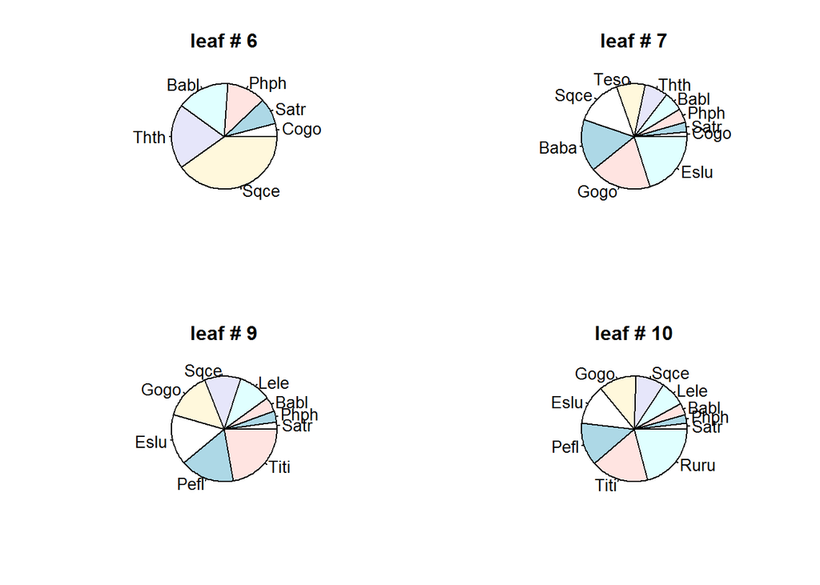

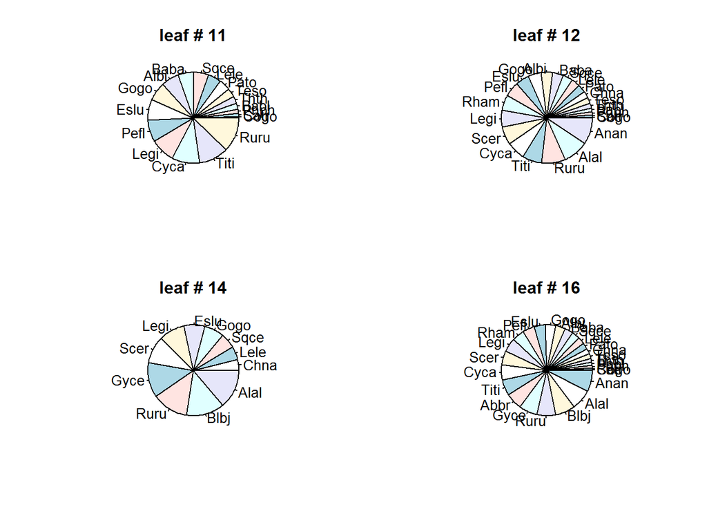

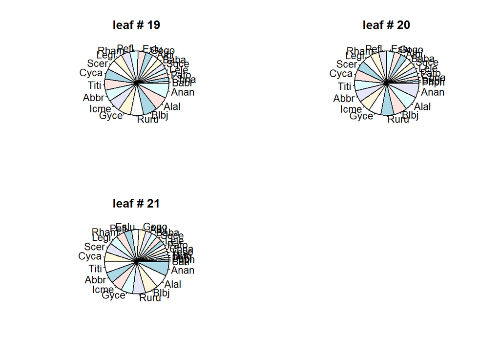

```r
par(mfrow = c(2, 2))
for (i in 1:length(groups.mrt)) {
  pie(which(leaf.sum[i, ] > 0), # 筛选的数据集
      radius = 1, # 在方框居中位置绘制,[-1, 1] | 长字符串 小数字
      main = paste("leaf #", groups.mrt[i])
      )
  }
```

```r
# 从 mvpart() 结果对象中提取 多元回归分析的结果
# rdaTest
# https://cran.r-project.org/src/contrib/Archive/MVPARTwrap/
# library(MVPARTwrap)
# ? MRT 多元回归树分析的修正输出
spe.ch.mvpart.wrap <- MRT(spe.ch.mvpart, # mvpart() 结果对象
                          percent = 10, # 判别 - 解释方差的贡献水平
                          species = colnames(spe)) # 用以 分区显示解释的方差
summary(spe.ch.mvpart.wrap) # 统计每列的基本信息
```

```
## Portion (%) of deviance explained by species for every particular node
##
## ~~~~~~~~~~~~~~~~~~~~~~~~~~~~~~~~~~~~~~~~~~~~~~~~~~~~~~
##                     --- Node 1 ---
##  Complexity(R2) 44.82089
##  ele>=341 ele< 341
##
## ~ Discriminant species :
##                            Satr        Phph       Babl        Alal
## % of expl. deviance 19.77533931 15.26700612 10.2177021 17.23790891
## Mean on the left     0.44606214  0.44096408  0.4127684  0.01160596
## Mean on the right    0.01205161  0.05962155  0.1007969  0.41681637
##
## ~ INDVAL species for this node: : left is 1, right is 2
##      cluster indicator_value probability
## Satr       1          0.9128       0.001
## Phph       1          0.8258       0.001
## Babl       1          0.7535       0.001
## Cogo       1          0.4036       0.018
## Alal       2          0.9729       0.001
## Gyce       2          0.9231       0.001
## Chna       2          0.7994       0.001
## Legi       2          0.7849       0.001
## Ruru       2          0.7844       0.001
## Blbj       2          0.7692       0.001
## Rham       2          0.7432       0.001
## Anan       2          0.7366       0.001
## Gogo       2          0.7289       0.001
## Cyca       2          0.6998       0.001
## Scer       2          0.6942       0.001
## Abbr       2          0.6923       0.001
## Albi       2          0.6200       0.005
## Baba       2          0.6170       0.004
## Eslu       2          0.5892       0.014
## Titi       2          0.5658       0.017
## Icme       2          0.5385       0.003
## Pefl       2          0.5268       0.023
## Pato       2          0.4803       0.021
##
## Sum of probabilities                 =  0.791
```

[output cut: 382 more lines]

```
##  1  2  4  5  7  9 11
##  1  1  1  1  1  1  4
##
## ~ Corresponding MRT leaf number for Indval cluster number:
## MRT leaf # 6 is Indval cluster no. 1
## MRT leaf # 7 is Indval cluster no. 2
## MRT leaf # 9 is Indval cluster no. 3
## MRT leaf # 10 is Indval cluster no. 4
## MRT leaf # 11 is Indval cluster no. 5
## MRT leaf # 12 is Indval cluster no. 6
## MRT leaf # 14 is Indval cluster no. 7
## MRT leaf # 16 is Indval cluster no. 8
## MRT leaf # 19 is Indval cluster no. 9
## MRT leaf # 20 is Indval cluster no. 10
## MRT leaf # 21 is Indval cluster no. 11
```

对结果的总结信息提供了每个节点的贡献度(用以解释方差 – 复杂性). 这些数值的总和称之为 总 R 方. 此外, 还可确定每个节点处的“判别式”物种 – 对解释方差的贡献最大. 同时, 在总结的信息中也提供了每个节点的两个分支的平均丰度信息(已进行数据转换), 因此可以观察分支的“判别式”物种.

### 4.12.4 Combining MRT and IndVal - 结合多元回归树方法与指示值方法

这比识别“判别式”物种的可视化效果更好好, 可以使用Holm校正来测试指标值的显着性并校正多次测试的 p 值.

```r
# Indicator species search on the MRT result
# 对 多元回归树分析结果进行 指示性物种 分析
(spe.ch.MRT.indval <- indval(spe.norm, # 物种数据集 已变换
                            spe.ch.mvpart$where)) # 簇分类向量
```

```
## $relfrq
##        6         7    9  10  11        12        14  16  19        20
## Cogo 0.5 1.0000000 0.00 0.0 1.0 0.3333333 0.0000000 0.5 0.0 0.0000000
## Satr 1.0 1.0000000 1.00 1.0 1.0 0.6666667 0.0000000 0.5 0.0 0.0000000
## Phph 0.5 1.0000000 1.00 1.0 1.0 1.0000000 0.0000000 1.0 0.0 0.6666667
## Babl 0.5 1.0000000 1.00 1.0 1.0 1.0000000 0.0000000 1.0 1.0 1.0000000
## Thth 0.5 1.0000000 0.00 0.0 0.5 0.3333333 0.0000000 0.5 0.0 0.0000000
## Teso 0.0 0.6666667 0.00 0.0 1.0 0.3333333 0.0000000 1.0 0.0 0.0000000
## Chna 0.0 0.0000000 0.00 0.0 0.0 0.3333333 0.3333333 1.0 1.0 1.0000000
## Pato 0.0 0.0000000 0.00 0.0 0.5 0.3333333 0.0000000 1.0 0.5 1.0000000
## Lele 0.0 0.0000000 0.25 1.0 1.0 0.6666667 0.3333333 1.0 1.0 1.0000000
## Sqce 0.5 0.6666667 0.50 1.0 1.0 1.0000000 1.0000000 1.0 1.0 1.0000000
## Baba 0.0 0.3333333 0.00 0.0 1.0 0.3333333 0.0000000 1.0 1.0 1.0000000
## Albi 0.0 0.0000000 0.00 0.0 0.5 0.3333333 0.0000000 1.0 1.0 1.0000000
## Gogo 0.0 0.3333333 0.25 1.0 1.0 0.6666667 0.6666667 1.0 1.0 1.0000000
## Eslu 0.0 0.3333333 0.50 0.5 0.5 0.6666667 0.3333333 1.0 1.0 1.0000000
## Pefl 0.0 0.0000000 0.25 0.5 0.5 0.6666667 0.0000000 1.0 1.0 1.0000000
## Rham 0.0 0.0000000 0.00 0.0 0.0 0.3333333 0.0000000 1.0 1.0 1.0000000
## Legi 0.0 0.0000000 0.00 0.0 0.5 0.3333333 0.3333333 1.0 1.0 1.0000000
## Scer 0.0 0.0000000 0.00 0.0 0.0 0.3333333 0.3333333 0.5 1.0 1.0000000
## Cyca 0.0 0.0000000 0.00 0.0 0.5 0.3333333 0.0000000 1.0 1.0 1.0000000
## Titi 0.0 0.0000000 0.25 0.5 1.0 1.0000000 0.0000000 1.0 1.0 1.0000000
## Abbr 0.0 0.0000000 0.00 0.0 0.0 0.0000000 0.0000000 0.5 1.0 1.0000000
## Icme 0.0 0.0000000 0.00 0.0 0.0 0.0000000 0.0000000 0.0 1.0 0.6666667
## Gyce 0.0 0.0000000 0.00 0.0 0.0 0.0000000 0.6666667 1.0 1.0 1.0000000
## Ruru 0.0 0.0000000 0.00 0.5 0.5 1.0000000 1.0000000 1.0 1.0 1.0000000
## Blbj 0.0 0.0000000 0.00 0.0 0.0 0.0000000 0.3333333 0.5 1.0 1.0000000
## Alal 0.0 0.0000000 0.00 0.0 0.0 0.3333333 1.0000000 1.0 1.0 1.0000000
## Anan 0.0 0.0000000 0.00 0.0 0.0 0.3333333 0.0000000 1.0 1.0 1.0000000
##             21
## Cogo 0.0000000
## Satr 0.3333333
## Phph 0.3333333
## Babl 0.6666667
## Thth 0.3333333
## Teso 0.3333333
## Chna 1.0000000
## Pato 1.0000000
## Lele 1.0000000
## Sqce 1.0000000
```

[output cut: 148 more lines]

```
## 0.5486736 0.3186028 0.1881971 0.3281683 0.3663375 0.3399939
##
## $pval
##  Cogo  Satr  Phph  Babl  Thth  Teso  Chna  Pato  Lele  Sqce  Baba  Albi
## 0.134 0.006 0.098 0.022 0.021 0.015 0.068 0.113 0.122 0.599 0.178 0.147
##  Gogo  Eslu  Pefl  Rham  Legi  Scer  Cyca  Titi  Abbr  Icme  Gyce  Ruru
## 0.363 0.359 0.534 0.032 0.059 0.178 0.018 0.068 0.087 0.002 0.017 0.344
##  Blbj  Alal  Anan
## 0.054 0.002 0.017
##
## $error
## [1] 0
##
## attr(,"class")
## [1] "indval"
```

```r
# spe.ch.MRT.indval$pval - Probability 概率
# 多次试验校正 p-values
# 调整P值以进行多重比较 - p.adjust()
# https://www.rdocumentation.org/packages/stats/versions/3.5.3/topics/p.adjust
pval.adj3 <- p.adjust(spe.ch.MRT.indval$pval)

# For each significant species, find the leaf with the highest IndVal
# 对于每个显著性的物种,查找具有最大 IndVal 值的叶子
spe.ch.MRT.indval$maxcls[which(pval.adj3 <= 0.05)] # 根据显著性筛选数据集
```

```
## named integer(0)
```

```r
# IndVal value in the best leaf for each significant species
# 每个显著性物种在重要叶子的 IndVal 数值
# spe.ch.MRT.indval$indcls[which(spe.ch.MRT.indval$pval <= 0.05)]
spe.ch.MRT.indval$indcls[which(pval.adj3 <= 0.05)]
```

```
## named numeric(0)
```

```r
# 基于多元回归树分析结果对象的划分 | 分区
spech.mvpart.g <- factor(spe.ch.mvpart$where)
levels(spech.mvpart.g) <- 1:length(levels(spech.mvpart.g)) # 因子化水平

# 通过列联表进行比较分析
# 使用交叉分类因子来构建每个因子水平组合的计数的列联表
table(spech.mvpart.g, spech.ward.g)
```

```
##               spech.ward.g
## spech.mvpart.g 1 2 3 4
##             1  2 0 0 0
##             2  3 0 0 0
##             3  4 0 0 0
##             4  2 0 0 0
##             5  0 2 0 0
##             6  0 3 0 0
##             7  0 0 0 3
##             8  0 2 0 0
##             9  0 0 2 0
##             10 0 0 3 0
##             11 0 0 3 0
```

[figure not shown]

```r
# Plot of the MRT clusters on a map of the Doubs River
drawmap(xy = spa,
        clusters = spech.mvpart.g,
        main = "Four MRT clusters along the Doubs River")
```

```r
# 输出结果又乱码 - 提示信息
```

## 4.13 MRT as a Monothetic Clustering Method - 多元回归树方法可以作为一种单元聚类方法

多元回归树分析为单元聚类提供了一个解决方案, 即一种无约束的聚类形式(其中, 树的每个筛分选择一个单一的响应变量). 使用物种数据作为响应和解释性变量来构建回归树. 这种方法可将同质化组成的位点和通过递增化的指示者物种的存在(或者相对丰度)来解释的位点划分成不同的组.

这种方法可以应用于’有-无’数据类型或者预转换的丰度响应数据; 解释性数据可能是二元(‘有-无’)类型或者定量类型(未转换或已转换), 相同的数据矩阵经过多种不同的数据变换之后也可以应用.

```r
# Method related to Williams & Lambert (1959) 关联分析:
# spe.pa (presence-absence) 作为响应和解释矩阵
spe.pa <- decostand(spe, "pa") # 物种数据集,'有-无'二进制数据变换, 矩阵
# Testing mvpart | Multivariate partitioning 多元变量分区 | Multivariate regression trees
# https://bookdown.org/forestgeoguest/mpart/mvpart.html
# https://cran.r-project.org/src/contrib/Archive/mvpart/
res.part1 <- mvpart(
    data.matrix(spe.pa) ~ ., # 符号表达式 - 映射关系 y ~ model | 响应数据集
    data = spe.pa, # 物种'有-无'数据集
    margin = 0.08, # 边距设置
    xv = "p", # 选择交叉验证的方法选择树形
    xvmult = 100  # 多重交叉验证的次数
  )
```

```
## X-Val rep : 1  2  3  4  5  6  7  8  9  10  11  12  13  14  15  16  17  18  19  20  21  22  23  24  25  26  27  28  29  30  31  32  33  34  35  36  37  38  39  40  41  42  43  44  45  46  47  48  49  50  51  52  53  54  55  56  57  58  59  60  61  62  63  64  65  66  67  68  69  70  71  72  73  74…
## Minimum tree sizes
## tabmins
##  6  7  9
##  2  3 95
```

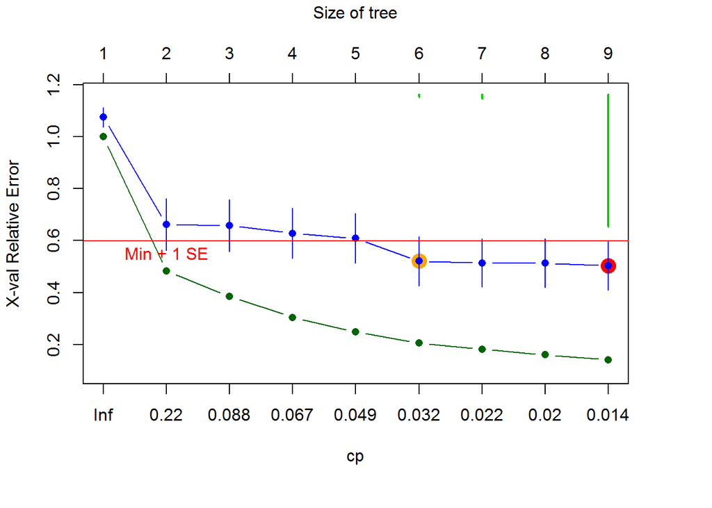

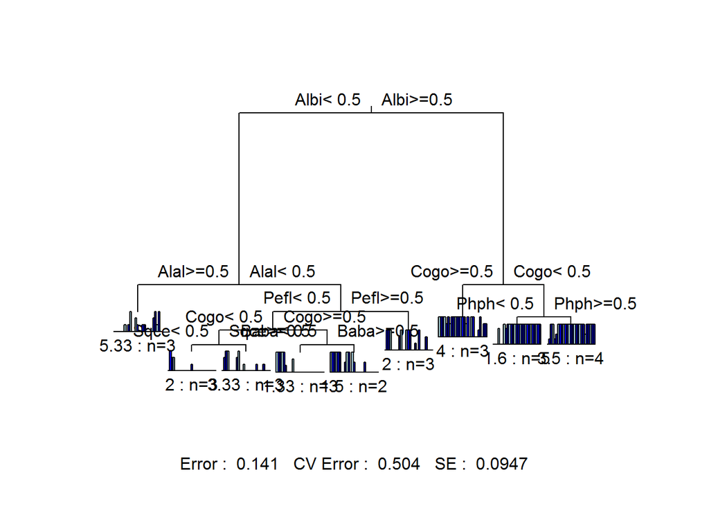

```r
head(res.part1$where) # 查看部分数据
```

```
##  1  2  3  4  5  6
##  7  7  7 12 12 12
```

```r
# Testing mvpart | Multivariate partitioning 多元变量分区 | Multivariate regression trees
# https://bookdown.org/forestgeoguest/mpart/mvpart.html
# https://cran.r-project.org/src/contrib/Archive/mvpart/
# spe.norm is the response, spe.pa is the explanatory matrix
res.part2 <- mvpart(
    data.matrix(spe.norm) ~ ., # 符号表达式 - 映射关系 y ~ model | 响应数据集
    data = spe.pa, # 解释性数据集
    margin = 0.08,  # 边距设置
    xv = "p", # 选择交叉验证的方法选择树形
    xvmult = 100  # 多重交叉验证的次数
  )
```

```
## X-Val rep : 1  2  3  4  5  6  7  8  9  10  11  12  13  14  15  16  17  18  19  20  21  22  23  24  25  26  27  28  29  30  31  32  33  34  35  36  37  38  39  40  41  42  43  44  45  46  47  48  49  50  51  52  53  54  55  56  57  58  59  60  61  62  63  64  65  66  67  68  69  70  71  72  73  74…
## Minimum tree sizes
## tabmins
##  2  3  4  5  6  7  8
## 33 30  9 13  4  2  9
```

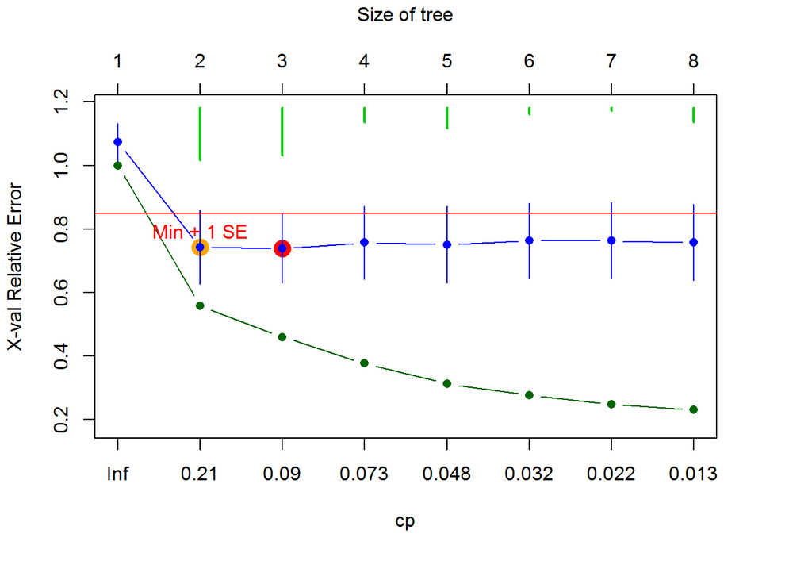

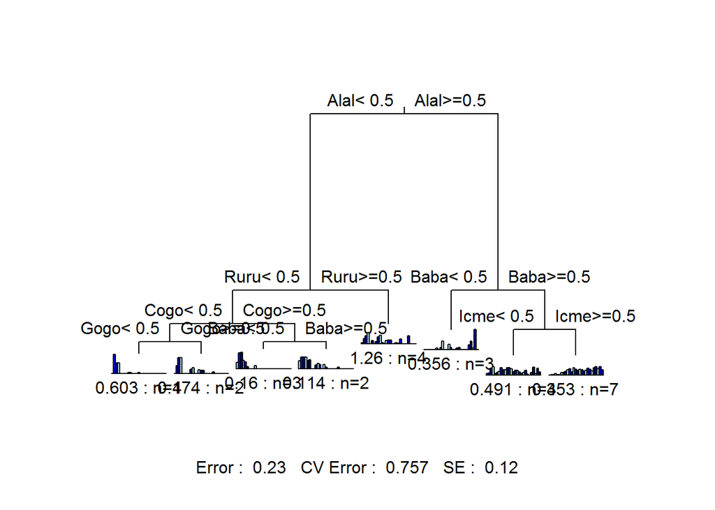

```r
head(res.part2$where) # 查看部分数据
```

```
##  1  2  3  4  5  6
##  5  5  5  6 10 10
```

```r
# Testing mvpart | Multivariate partitioning 多元变量分区 | Multivariate regression trees
# https://bookdown.org/forestgeoguest/mpart/mvpart.html
# https://cran.r-project.org/src/contrib/Archive/mvpart/
res.part3 <- mvpart(
    data.matrix(spe.norm) ~ ., # 符号表达式 - 映射关系 y ~ model | 响应数据集
    data = spe, # 解释性数据集
    margin = 0.08, # 边距设置
    xv = "p", # 选择交叉验证的方法选择树形
    xvmult = 100 # 多重交叉验证的次数
  )
```

```
## X-Val rep : 1  2  3  4  5  6  7  8  9  10  11  12  13  14  15  16  17  18  19  20  21  22  23  24  25  26  27  28  29  30  31  32  33  34  35  36  37  38  39  40  41  42  43  44  45  46  47  48  49  50  51  52  53  54  55  56  57  58  59  60  61  62  63  64  65  66  67  68  69  70  71  72  73  74…
## Minimum tree sizes
## tabmins
##  2  3  4  5  6  7  8
##  7  1  1  8 33 12 38
```

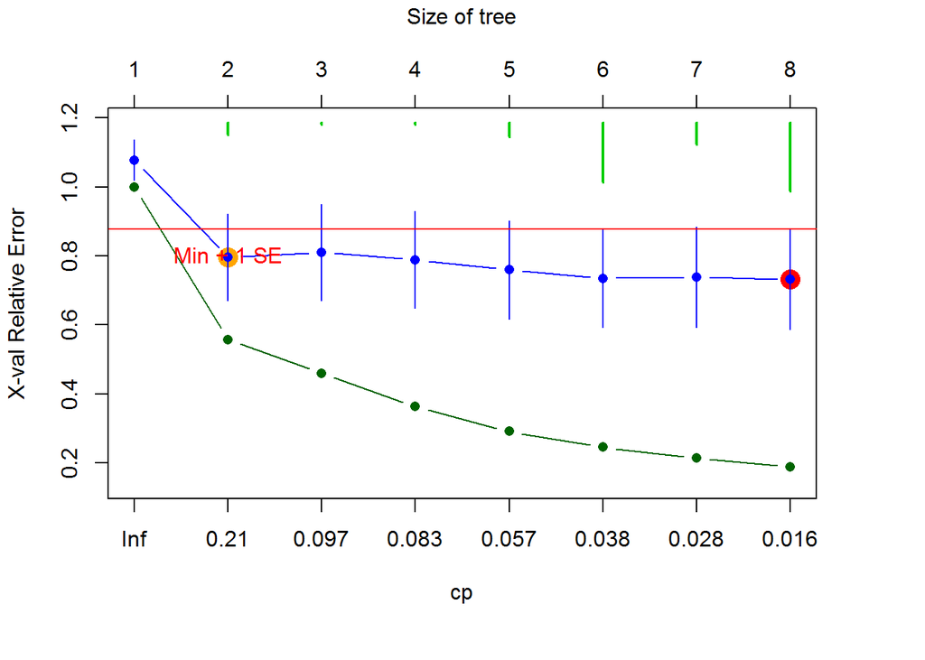

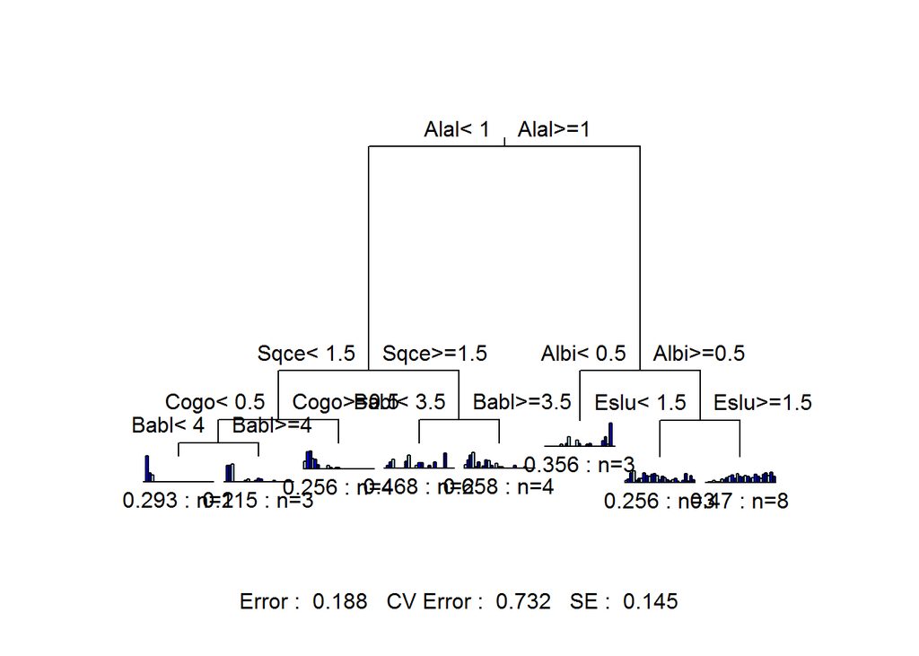

```r
# 对象 - 组 关系
head(res.part1$where) # 查看部分数据
```

```
##  1  2  3  4  5  6
##  7  7  7 12 12 12
```

```r
res.part1.g <- factor(res.part1$where)
levels(res.part1.g) <- 1:length(levels(res.part1.g)) # 因子化水平
# 比较组间的非限制性聚类
# 通过列联表进行比较分析
# 使用交叉分类因子来构建每个因子水平组合的计数的列联表
table(res.part1.g, spech.ward.g)
```

```
##            spech.ward.g
## res.part1.g 1 2 3 4
##           1 0 0 0 3
##           2 3 0 0 0
##           3 2 1 0 0
##           4 3 0 0 0
##           5 1 1 0 0
##           6 2 1 0 0
##           7 0 3 0 0
##           8 0 0 5 0
##           9 0 1 3 0
```

```r
table(res.part1.g, spech.ward.gk)
```

```
##            spech.ward.gk
## res.part1.g 1 2 3 4
##           1 0 0 0 3
##           2 3 0 0 0
##           3 2 1 0 0
##           4 3 0 0 0
##           5 2 0 0 0
##           6 2 1 0 0
##           7 0 3 0 0
##           8 0 0 5 0
##           9 0 1 3 0
```

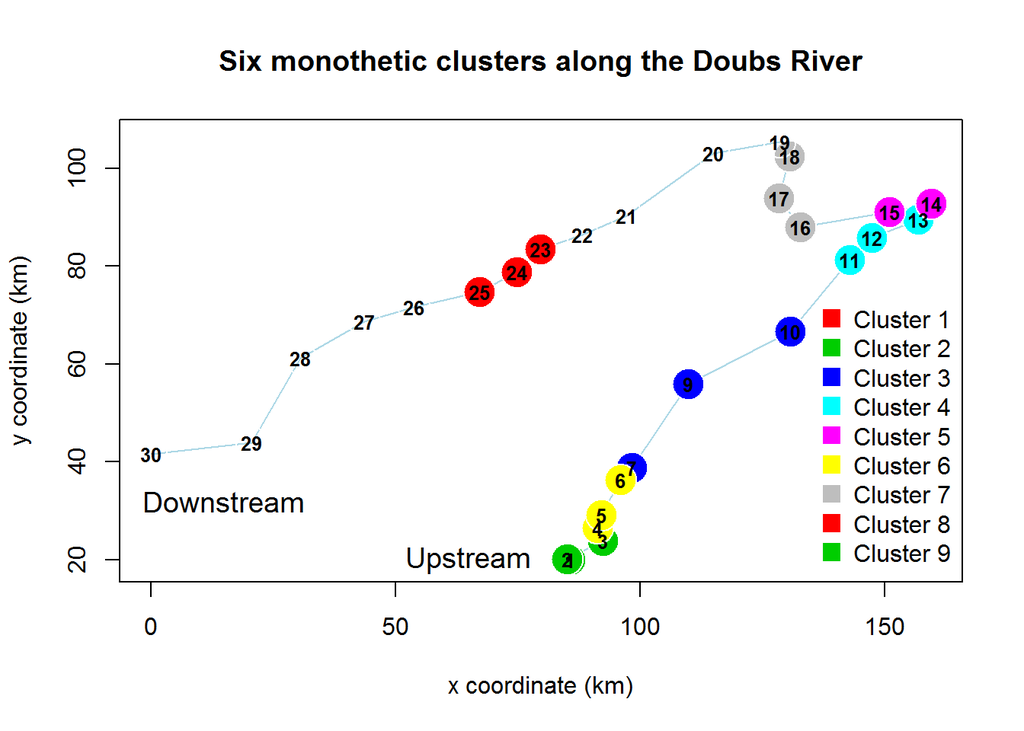

```r
#绘制多元回归树分析的地理位置分布图
drawmap3(xy = spa, # 地理位置信息 - 经纬度
        clusters = res.part1.g, # 聚类向量
        main = "Six monothetic clusters along the Doubs River")
```

```r
# Clustering with sequential constraint - 连续性约束聚类
# 本文不介绍 使用多元回归树方法进行序列聚类 - Sequential clustering using MRT
# Testing mvpart | Multivariate partitioning 多元变量分区 | Multivariate regression trees
# https://bookdown.org/forestgeoguest/mpart/mvpart.html
# https://cran.r-project.org/src/contrib/Archive/mvpart/
spe.ch.seq <- mvpart(
  as.matrix(spe) ~ dfs, # 符号表达式 - 映射关系 y ~ model | 响应数据集
  env,  # 解释性数据集
  cp = 0, # prune.rpart() 成本复杂度修剪 - 通过复杂度剪切掉最不重要的分区 - 复杂度参数
  xv = "pick", # 选择交叉验证的方法选择树形
  margin = 0.08, # 边距设置
  xval = nrow(spe),  # 交叉验证的数量 - 交叉验证的向量
  xvmult = 100,  # 多重交叉验证的次数
  which = 4) # 分割标签和绘制的位置:1 居中，2 左，3 右，4双端
```

```
## X-Val rep : 1  2  3  4  5  6  7  8  9  10  11  12  13  14  15  16  17  18  19  20  21  22  23  24  25  26  27  28  29  30  31  32  33  34  35  36  37  38  39  40  41  42  43  44  45  46  47  48  49  50  51  52  53  54  55  56  57  58  59  60  61  62  63  64  65  66  67  68  69  70  71  72  73  74…
## Minimum tree sizes
## tabmins
##  2  3  4  5  6  8
##  1  1 25 36 27 10
```

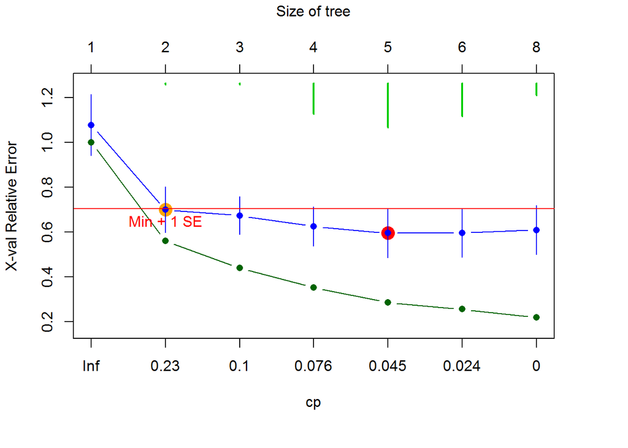

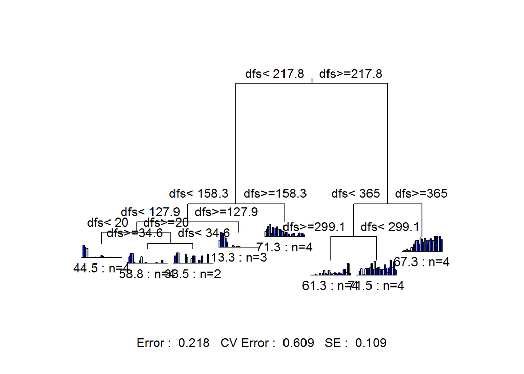

```r
summary(spe.ch.seq)
```

```
## Call:
## mvpart(form = as.matrix(spe) ~ dfs, data = env, xv = "pick",
##     xval = nrow(spe), xvmult = 100, margin = 0.08, which = 4,
##     cp = 0)
##   n= 29
##
##           CP nsplit rel error    xerror       xstd
## 1 0.44029924      0 1.0000000 1.0780227 0.13666091
## 2 0.12087218      1 0.5597008 0.6998382 0.10144546
## 3 0.08681821      2 0.4388286 0.6733955 0.08400480
## 4 0.06666020      3 0.3520104 0.6246926 0.08742785
## 5 0.03001876      4 0.2853502 0.5948954 0.10975762
## 6 0.01855488      5 0.2553314 0.5963039 0.10884670
## 7 0.00000000      7 0.2182217 0.6090153 0.10925806
##
## Node number 1: 29 observations,    complexity param=0.4402992
##   Means=0.5172,1.966,2.345,2.517,0.5172,0.6552,0.6207,0.8966,1.483,1.931,1.483,0.931,1.897,1.379,1.241,1.138,1,0.7241,0.8621,1.552,0.8966,0.6207,1.31,2.172,1.069,1.966,0.931, Summed MSE=66.57788
##   left son=2 (17 obs) right son=3 (12 obs)
##   Primary splits:
##       dfs < 217.8  to the left,  improve=0.4402992, (0 missing)
##
## Node number 2: 17 observations,    complexity param=0.0666602
##   Means=0.8824,3.294,3.647,3.529,0.8235,1,0.1176,0.6471,1.294,1.529,0.6471,0.4706,0.7647,0.7059,0.7647,0.1765,0.1765,0.1176,0.1765,0.6471,0,0,0.05882,0.8824,0,0.2353,0.1176, Summed MSE=28.21453
##   left son=4 (13 obs) right son=5 (4 obs)
##   Primary splits:
##       dfs < 158.35 to the left,  improve=0.2683322, (0 missing)
##
## Node number 3: 12 observations,    complexity param=0.1208722
##   Means=0,0.08333,0.5,1.083,0.08333,0.1667,1.333,1.25,1.75,2.5,2.667,1.583,3.5,2.333,1.917,2.5,2.167,1.583,1.833,2.833,2.167,1.5,3.083,4,2.583,4.417,2.083, Summed MSE=50.08333
##   left son=6 (8 obs) right son=7 (4 obs)
##   Primary splits:
##       dfs < 365.05 to the left,  improve=0.3883111, (0 missing)
##
## Node number 4: 13 observations,    complexity param=0.03001876
##   Means=0.6154,3.538,3.692,3.308,0.7692,0.3846,0,0,0.6923,1.231,0.07692,0,0.4615,0.6923,0.5385,0,0,0.1538,0,0.5385,0,0,0,0.7692,0,0,0, Summed MSE=21.51479
##   left son=8 (10 obs) right son=9 (3 obs)
##   Primary splits:
##       dfs < 127.9  to the left,  improve=0.2072241, (0 missing)
##
## Node number 5: 4 observations
```

[output cut: 25 more lines]

```
##
## Node number 16: 4 observations
##   Means=0,4.25,3.5,3.25,0,0,0,0,0,0.25,0,0,0.25,0.75,0.5,0,0,0,0,0.25,0,0,0,0,0,0,0, Summed MSE=11.125
##
## Node number 17: 6 observations,    complexity param=0.01855488
##   Means=0.1667,2.333,3.333,3.333,0.1667,0,0,0,1.5,2.167,0,0,0.6667,0.8333,0.8333,0,0,0.3333,0,1,0,0,0,1.667,0,0,0, Summed MSE=21.94444
##   left son=34 (4 obs) right son=35 (2 obs)
##   Primary splits:
##       dfs < 34.6   to the right, improve=0.2993671, (0 missing)
##
## Node number 34: 4 observations
##   Means=0.25,2.25,3.25,3.25,0.25,0,0,0,0.75,2.25,0,0,0.25,0,0,0,0,0,0,0.25,0,0,0,1,0,0,0, Summed MSE=14.6875
##
## Node number 35: 2 observations
##   Means=0,2.5,3.5,3.5,0,0,0,0,3,2,0,0,1.5,2.5,2.5,0,0,1,0,2.5,0,0,0,3,0,0,0, Summed MSE=16.75
```

```r
# 组 成分 (终端节点标签)
(gr <- spe.ch.seq$where) # 直接显示全部信息
```

```
##  1  2  3  4  5  6  7  9 10 11 12 13 14 15 16 17 18 19 20 21 22 23 24 25 26
##  5  5  5  5  8  8  7  7  7  7  9  9  9 10 10 10 10 14 14 14 14 13 13 13 13
## 27 28 29 30
## 15 15 15 15
```

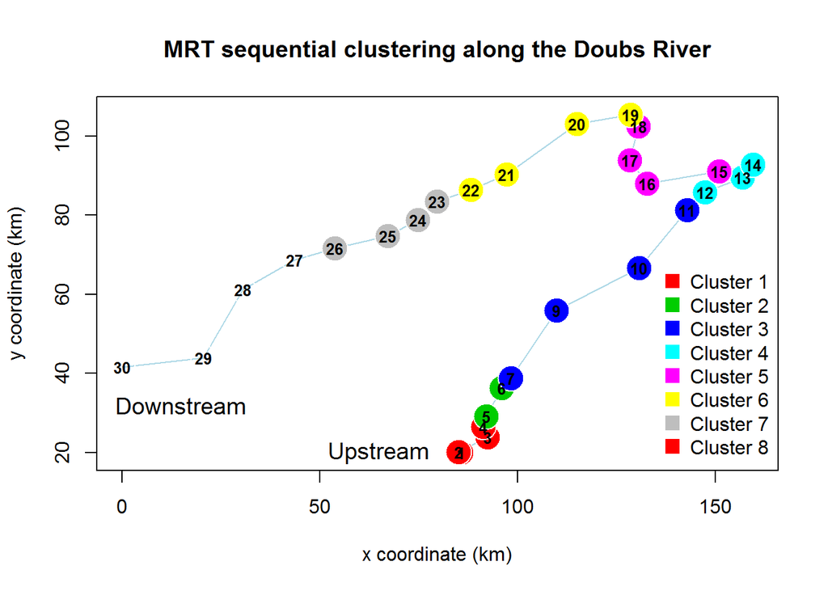

```r
# 重新编码簇
aa <- 1
gr2 <- rep(1, length(gr)) # 生成重复向量
for (i in 2 : length(gr)) {
    if (gr[i] !=  gr[i-1]) aa <- aa + 1
    gr2[i] <- aa
    }
# 绘制聚类的地理位置图
drawmap3(xy = spa, # 地理位置信息 - 经纬度
        clusters = gr2, # 聚类的簇分类向量
        main = "MRT sequential clustering along the Doubs River")
```

## 4.14 Sequential Clustering - 连续性聚类

在数据以空间(横断面)或时间顺序呈现的情况下查找组时可以考虑邻接信息, 并且在连续性时可以考虑连续性信息以及系列.

连续性聚类可以通过 MRT 的方式进行计算.

本小节将应用为地层研究开发的具有邻接约束的聚类方法, 并称为 CONISS. 使用分析包 rioja 中的 chclust() 进行分析.

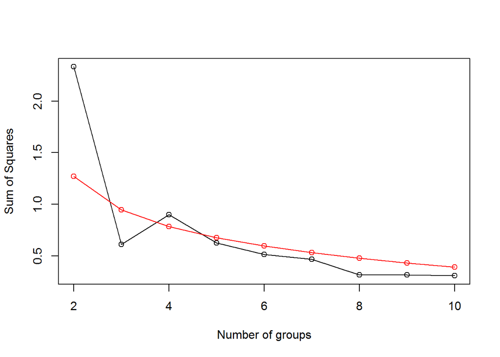

```r
# 对 percentage difference 相异矩阵 使用默认方法 - CONISS
# https://www.rdocumentation.org/packages/vegan/versions/2.4-2/topics/vegdist
# vegdist() 计算相异矩阵, 默认距离方法 - bray
# https://www.rdocumentation.org/packages/rioja/versions/0.9-15.2/topics/chclust
# chclust - Constrained Hierarchical Clustering - 约束性层次聚类
spe.chcl <- chclust(vegdist(spe)) # 使用默认 聚合方法 - coniss | "coniss" or "conslink".

# 将等级分类的分散度与从断棒模型中获得的分散度进行比较
# https://www.rdocumentation.org/packages/vegan/versions/1.11-0/topics/screeplot.cca
# 为下文 k 值提供依据
bstick(spe.chcl, # 约束性层次聚类的结果对象
       10, # 展示的 组/簇 数量
       plot = T)
```

```r
k <- 4 # 设置聚类数量
(gr4 <- cutree(spe.chcl, k = k)# 切分聚类结果对象
  ) # 直接显示全部信息 -- 向量的形式
```

```
##  1  2  3  4  5  6  7  9 10 11 12 13 14 15 16 17 18 19 20 21 22 23 24 25 26
##  1  1  1  1  1  1  1  1  1  1  1  1  1  2  2  2  2  2  2  2  2  3  3  3  4
## 27 28 29 30
##  4  4  4  4
```

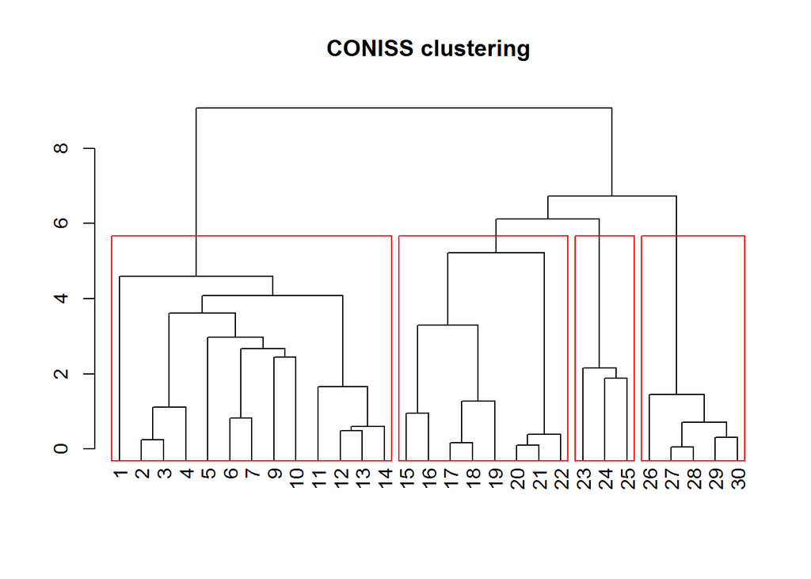

```r
# 绘制树形图
plot(spe.chcl,
     hang = -1, # 改变 横轴的位置? 尝试(-1,0,1)
     main = "CONISS clustering")
rect.hclust(spe.chcl, k = k) # 添加层次聚类结果的矩阵框
```

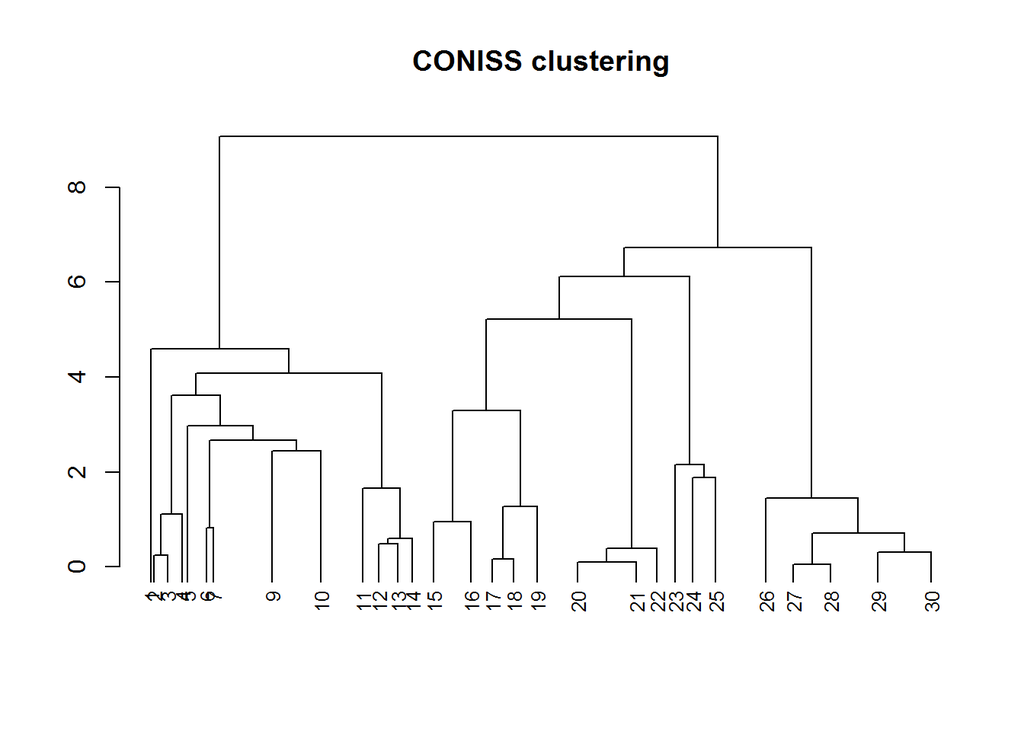

```r
# 绘制树形图
plot(spe.chcl,
     xvar = env$dfs,
     hang = -1,
     main = "CONISS clustering",
     cex = 0.8
     )
```

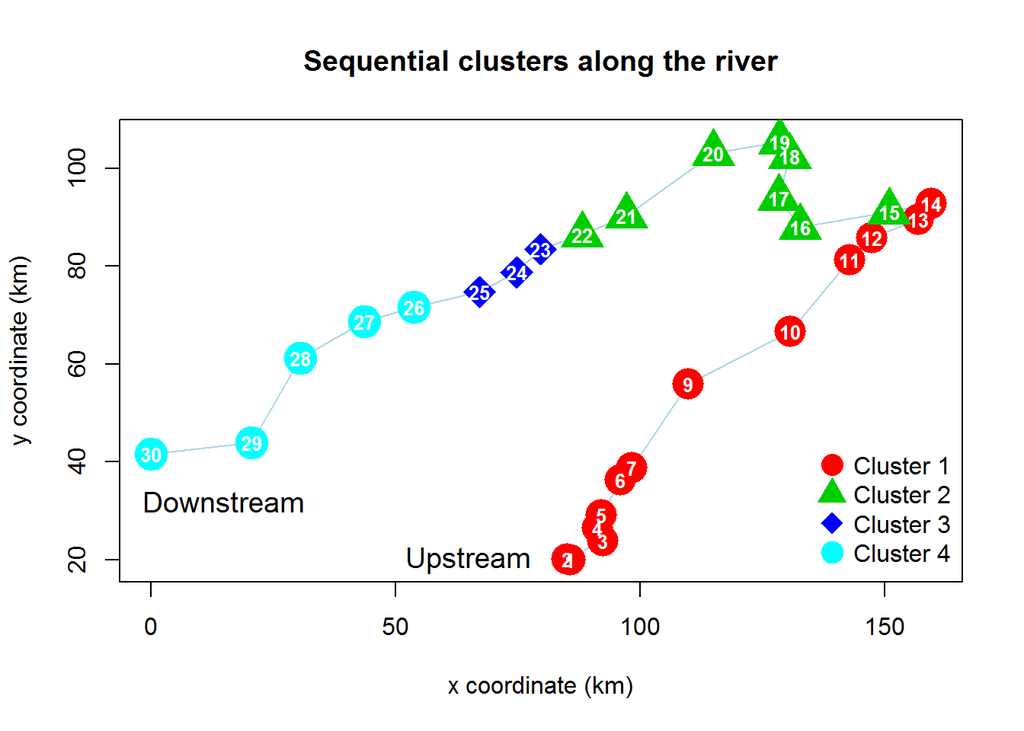

```r
# 绘制聚类的地理位置图
drawmap(xy = spa, # 地理位置信息 - 经纬度
        clusters = gr4,  # 聚类的簇分类向量
        main = "Sequential clusters along the river")
```

## 4.15 Fuzzy Clustering - 模糊聚类

在本章的开头, 将通过聚类方法或者的聚类簇定义为非重叠的实体. 这种定义是关注不连续性的结果(**如果关注连续性会有什么样不同的结果?**). 然而, 还有另外一种聚类方法, 有时聚类簇限制(界限)没有想象中的那么清晰. 在这种情况下, 同一个对象可能在不同程度上属于两个或者多个组的成员. 因此, 本小节提出了一种不同的层次和非层次方法, 即模糊聚类方法. 以下内容仅作相关简短的介绍.

### 4.15.1 Fuzzy c-means Using Package cluster’s Function fanny() - 使用 cluster 分析包中的 fanny() 函数计算**模糊 c-均值**

与传统一个对象仅属于一个聚类簇不同, c-means 聚类将一系列成员值与所有对象相关联, 以衡量其在各种集群中的成员关系的强度. 一个对象可以与某一聚类簇有强相关性, 同时也可以与另一个分类簇具有相对较弱的相关性.

两种分析分析方式: cluster 中的 fanny() 和 e1071 中的 cmeans(). fanny() 既可以接受’位点-物种’类型数据, 也可以接受’相异性矩阵’.

```r
k <- 4      # 设置聚类数量
spe.fuz <- fanny(spe.ch, # 物种弦距离矩阵
                 k = k, # 聚类数量
                 memb.exp = 1.5) # 严格大于1,指定拟合标准中使用的隶属指数
summary(spe.fuz) # 统计每列的基本信息
```

```
## Fuzzy Clustering object of class 'fanny' :
## m.ship.expon.      1.5
## objective     6.065589
## tolerance        1e-15
## iterations         115
## converged            1
## maxit              500
## n                   29
## Membership coefficients (in %, rounded):
##    [,1] [,2] [,3] [,4]
## 1    42   28   13   18
## 2    86    9    2    3
## 3    86   10    2    2
## 4    66   25    4    5
## 5    17   43   20   20
```

[output cut: 72 more lines]

```r
# Site fuzzy membership - 位点 模糊 关系
head(spe.fuz$membership) # 查看部分数据
```

```
##        [,1]       [,2]       [,3]       [,4]
## 1 0.4198329 0.27938150 0.12507006 0.17571551
## 2 0.8633340 0.09160712 0.01872811 0.02633079
## 3 0.8600971 0.09794009 0.01766820 0.02429460
## 4 0.6610447 0.24709547 0.04069775 0.05116203
## 5 0.1708162 0.42786571 0.20384018 0.19747787
## 6 0.4699142 0.40943844 0.05307161 0.06757579
```

```r
# Nearest crisp clustering - 最近的清晰 类分支
head(spe.fuz$clustering) # 查看部分数据
```

```
## 1 2 3 4 5 6
## 1 1 1 1 2 1
```

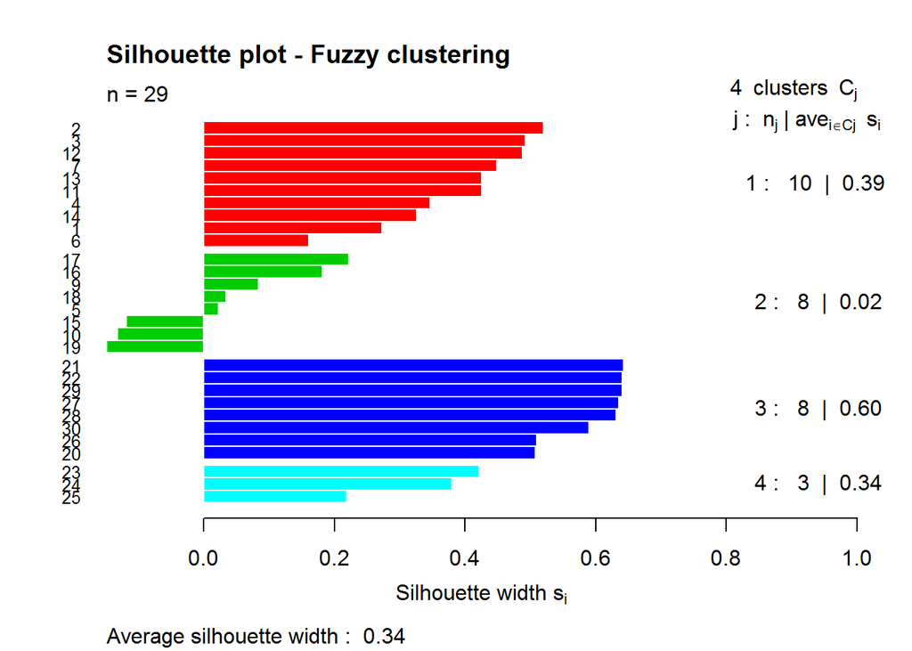

```r
spefuz.g <- spe.fuz$clustering

# 画出轮廓图
# https://www.rdocumentation.org/packages/cluster/versions/2.0.8/topics/silhouette
plot(
  silhouette(spe.fuz), # 提取轮廓信息
  main = "Silhouette plot - Fuzzy clustering",
  cex.names = 0.8,
  col = spe.fuz$silinfo$widths + 1
  )
```

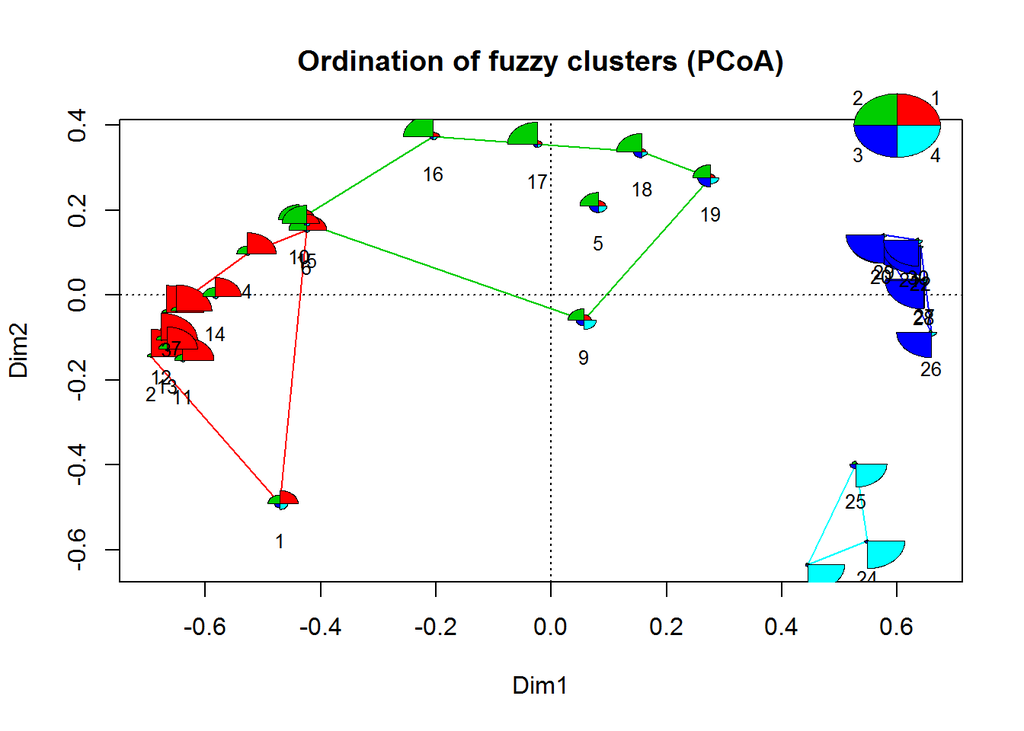

```r
# 模糊聚类排序 - PCoA
# Step 1:鱼类物种数据集的弦距离矩阵的 PCOA 排序分析
# https://www.rdocumentation.org/packages/stats/versions/3.5.3/topics/cmdscale
# 矩阵的经典多维缩放
dc.pcoa <- cmdscale(spe.ch)
# https://www.rdocumentation.org/packages/vegan/versions/2.4-2/topics/scores
# 获取排序结果的物种或位点的分值
dc.scores <- scores(dc.pcoa, # 排序结果
                    choices = c(1, 2)) # 选择信息获取的轴方向
# Step 2: 对模糊聚类结果进行排序绘图
plot(dc.scores,
     type = "n", #不绘图
     main = "Ordination of fuzzy clusters (PCoA)")
abline(h = 0, lty = "dotted")
abline(v = 0, lty = "dotted")
# Step 3: 表示模糊聚类结果
for (i in 1:k) {
  gg <- dc.scores[spefuz.g == i, ]
  # 计算位于指定点集的凸包上的点子集
  # https://www.rdocumentation.org/packages/grDevices/versions/3.5.3/topics/chull
  hpts <- chull(gg)
  hpts <- c(hpts, hpts[1])
  lines(gg[hpts, ], col = i + 1)
  }
stars( # 绘制星图或段图 - Star (Spider/Radar) Plots And Segment Diagrams
  spe.fuz$membership, # 矩阵类型数据
  location = dc.scores, # 必须含有两列
  key.loc = c(0.6, 0.4), # 单位键 坐标
  key.labels = 1:k, # 单位键 标签
  draw.segments = TRUE,
  add = TRUE, # 添加'星图'
  scale = FALSE, # 数据变换 | T 矩阵中的数据独立缩放; F 已经是数据变换之后的数据集
  len = 0.075, # 长度或者半径的尺度印祖
  col.segments = 2:(k + 1) # 指定颜色
  )
```

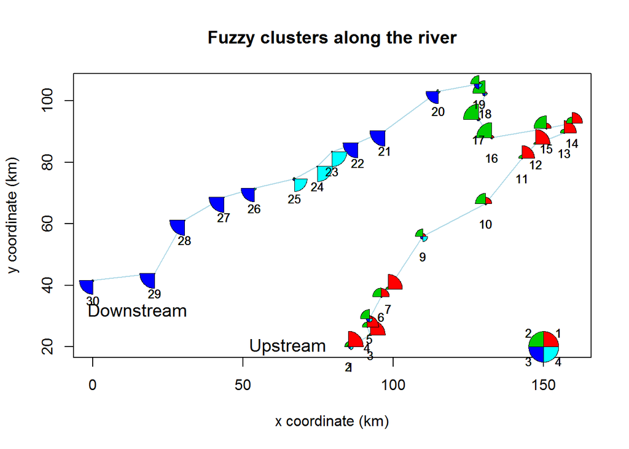

```r
# 聚类地理位置图
plot(
  spa, # 地理信息数据 - 经纬度
  type = "n",
  main = "Fuzzy clusters along the river",
  xlab = "x coordinate (km)",
  ylab = "y coordinate (km)"
  )
lines(spa, col = "light blue")
text(65, 20, # 位置
     "Upstream", cex = 1.2)
text(15, 32, # 位置
     "Downstream", cex = 1.2)
# Add sectors to represent fuzzy membership
for (i in 1:k) {
  # 绘制星图或段图 - Star (Spider/Radar) Plots And Segment Diagrams
  stars(
    spe.fuz$membership,
    location = spa,
    key.loc = c(150, 20),
    key.labels = 1:k,
    draw.segments = TRUE,
    add = TRUE,
    # scale = FALSE,  # 数据变换 | T 矩阵中的数据独立缩放; F 已经是数据变换之后的数据集
    len = 5,
    col.segments = 2:(k + 1) # 指定颜色
    )
  }
```

### 4.15.2 Noise Clustering Using the vegclust() Function - 使用 vegclust() 进行噪声聚类分析

在不同的模型下, 对群落数据应用非层次或层次模糊聚类分析的方法. 噪音聚类 – 它允许考虑异常值，即未分类的对象

```r
k <- 4 # 聚类个数
# 创建噪音聚类 - 4 分类
# Perform 30 starts from random seeds and keep the best solution
#?vegclust
# https://www.rdocumentation.org/packages/vegclust/versions/1.7.7/topics/vegclust
# 对植被数据执行硬或模糊聚类
spe.nc <- vegclust(
  spe.norm,
  mobileCenters = k, # 数字, 种子向量, 坐标
  m = 1.5,
  dnoise = 0.75, # 到噪声簇的距离
  method = "NC", # 聚类模型
  nstart = 30 # 选择多少个随机数据集
  )
head(spe.nc)
```

```
## $mode
## [1] "raw"
##
## $method
## [1] "NC"
##
## $m
## [1] 1.5
##
## $dnoise
## [1] 0.75
##
## $eta
## NULL
##
```

[output cut: 31 more lines]

```r
# Medoids of species - 物种的中心点
(medoids <- spe.nc$mobileCenters) # 直接显示全部数据
```

```
##            Cogo        Satr        Phph       Babl         Thth
## M1 0.0984352235 0.173550473 0.319626089 0.38192138 0.0607670789
## M2 0.0006929025 0.007103872 0.008189517 0.01363881 0.0005638036
## M3 0.0004152581 0.010214605 0.031453127 0.07732242 0.0069171968
## M4 0.1028163109 0.540612136 0.540341435 0.45637139 0.1182507850
##           Teso         Chna         Pato       Lele      Sqce        Baba
## M1 0.187795176 0.0695053471 0.2663071022 0.27500975 0.2212414 0.209287275
## M2 0.001278711 0.0567667839 0.0017004224 0.06516530 0.3266520 0.002005971
## M3 0.008325404 0.1057341520 0.0942217174 0.14468606 0.2018074 0.238362148
## M4 0.060771654 0.0001548584 0.0009715044 0.04938405 0.1114964 0.015497915
##            Albi       Gogo       Eslu        Pefl         Rham
## M1 0.2056548299 0.17617624 0.09797881 0.168860984 0.0937864033
## M2 0.0014790855 0.17936656 0.06337247 0.003638281 0.0015371229
## M3 0.1285878026 0.28246431 0.20536968 0.168104023 0.2163683182
## M4 0.0003903745 0.04374513 0.05448639 0.033424714 0.0001790356
##            Legi         Scer         Cyca        Titi         Abbr
## M1 0.0756369870 0.0210532610 0.0754959876 0.113490565 0.0110721505
## M2 0.0566539718 0.0617591748 0.0008504256 0.006465398 0.0008770803
## M3 0.1864897675 0.1295064175 0.1569867454 0.258605689 0.1917064163
## M4 0.0002730399 0.0008351305 0.0002708446 0.035207319 0.0000730529
##            Icme         Gyce       Ruru         Blbj         Alal
## M1 1.909594e-04 0.0355483255 0.20736790 1.124056e-02 0.1295886644
## M2 2.847318e-04 0.1721711229 0.32689166 5.662450e-02 0.7384310069
## M3 1.298064e-01 0.2614426418 0.32287965 2.236453e-01 0.3267953454
## M4 8.142068e-06 0.0001240484 0.01405942 7.662661e-05 0.0003635408
##            Anan
## M1 0.0589373006
## M2 0.0010222059
## M3 0.1836577872
## M4 0.0000987221
```

```r
# Fuzzy membership matrix - 模糊关系矩阵
head(spe.nc$memb) # 查看部分数据
```

```
##            M1          M2          M3        M4          N
## 1 0.081840485 0.050304826 0.046656416 0.2896135 0.53158479
## 2 0.008623480 0.001895951 0.001913626 0.9678957 0.01967124
## 3 0.007778461 0.001373933 0.001469773 0.9753865 0.01399133
## 4 0.044894043 0.005546477 0.007342457 0.8936770 0.04854007
## 5 0.337926830 0.070136653 0.159408914 0.1063817 0.32614586
## 6 0.139007746 0.012473929 0.017089952 0.7447016 0.08672677
```

```r
# Cardinality of fuzzy clusters - 模糊聚类的基数
head(spe.nc$size) # 查看部分数据
```

```
##       M1       M2       M3       M4
## 4.953399 3.212701 8.539570 9.729186
```

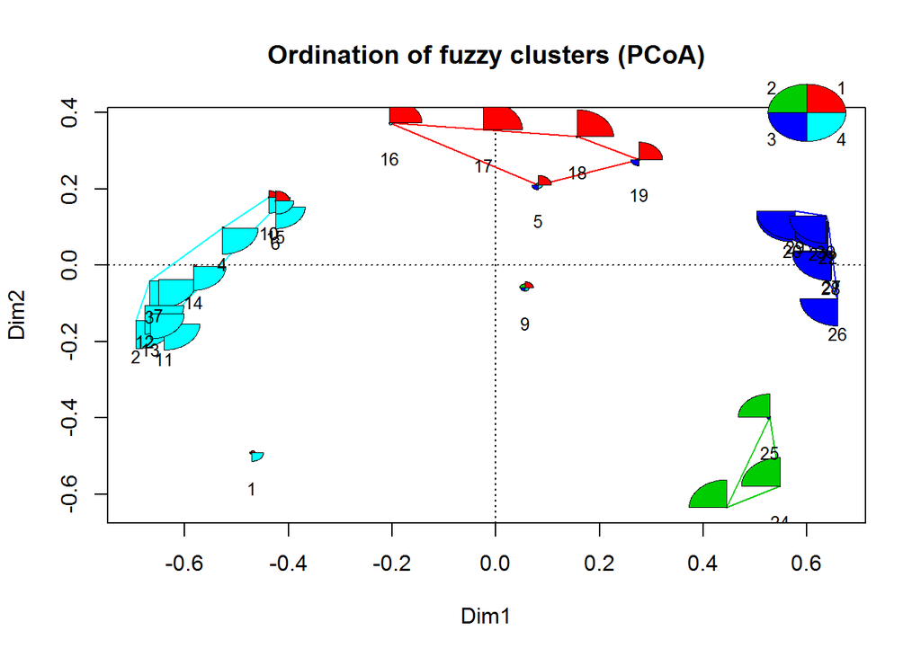

```r
# 获取硬关系向量
spefuz.g <- defuzzify(spe.nc$memb)$cluster
clNum <- as.numeric(as.factor(spefuz.g))

# 模糊聚类结果的排序 - PCOA
plot(dc.scores,
     main = "Ordination of fuzzy clusters (PCoA)",
     type = "n"
     )
abline(h = 0, lty = "dotted")
abline(v = 0, lty = "dotted")
for (i in 1:k) {
  gg <- dc.scores[clNum == i, ]
  # 计算位于指定点集的凸包上的点子集
  # https://www.rdocumentation.org/packages/grDevices/versions/3.5.3/topics/chull
  hpts <- chull(gg)
  hpts <- c(hpts, hpts[1])
  lines(gg[hpts, ], col = i + 1)
  }
stars( # 绘制星图或段图 - Star (Spider/Radar) Plots And Segment Diagrams
  spe.nc$memb[, 1:4],
  location = dc.scores,
  key.loc = c(0.6, 0.4),
  key.labels = 1:k,
  draw.segments = TRUE,
  add = TRUE,
  # scale = FALSE,  # 数据变换 | T 矩阵中的数据独立缩放; F 已经是数据变换之后的数据集
  len = 0.075,
  col.segments = 2:(k + 1) # 指定颜色
  )
```

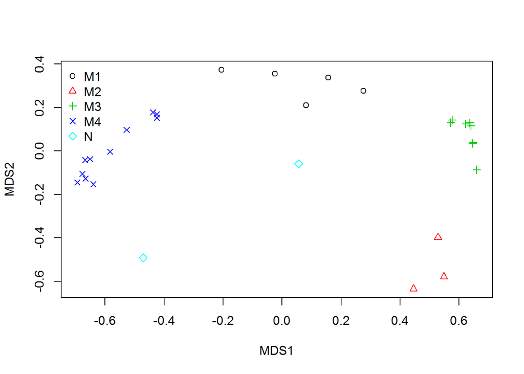

```r
# Defuzzified site plot - 已解除模糊的位点图
plot(
  dc.pcoa,
  xlab = "MDS1",
  ylab = "MDS2",
  pch = clNum,
  col = clNum)
legend(
  "topleft",
  col = 1:(k + 1),
  pch = 1:(k + 1),
  legend = levels(as.factor(spefuz.g)), #因子化
  bty = "n")
```

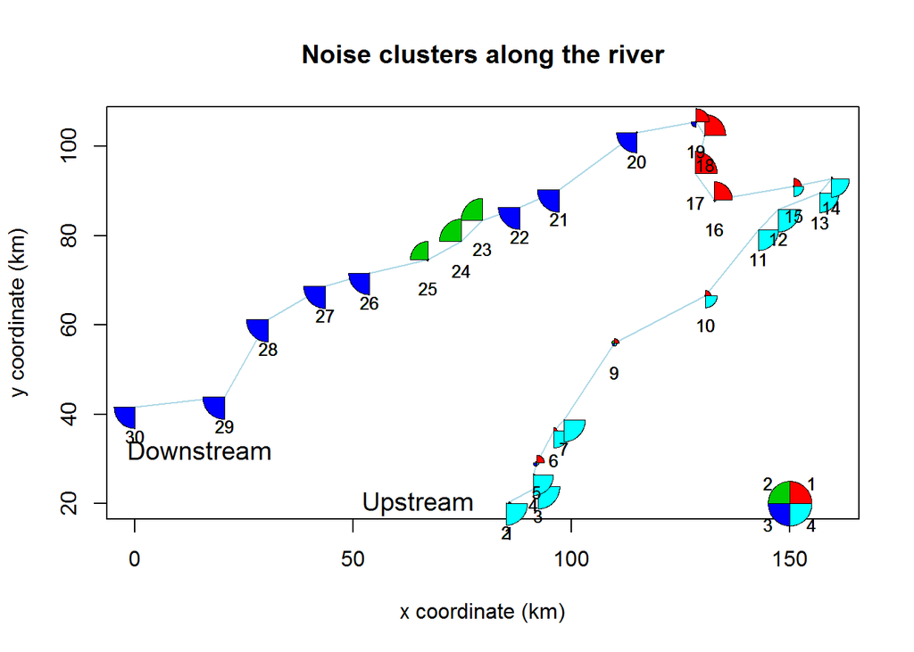

```r
# drawmap() ???
plot(
  spa, # 物种空间地理数据
  type = "n",
  main = "Noise clusters along the river",
  xlab = "x coordinate (km)",
  ylab = "y coordinate (km)"  )
lines(spa, col = "light blue")
text(65, 20, "Upstream", cex = 1.2)
text(15, 32, "Downstream", cex = 1.2)
# 添加扇区以表示模糊成员身份
for (i in 1:k) {
  stars( # 绘制星图或段图 - Star (Spider/Radar) Plots And Segment Diagrams
    spe.nc$memb[, 1:4],
    location = spa,
    key.loc = c(150, 20),
    key.labels = 1:k,
    draw.segments = TRUE,
    add = TRUE,
    len = 5,
    col.segments = 2:(k + 1) # 指定颜色
    )
  }
```

虽然“硬”聚类在生态学中可能看起来有点不切实际, 但当需要一个需要明确分配站点的类型学或决策工具时, 它的应用会有很大的帮助.

如果模糊聚类的目的是描述站点之间的相似关系, 则模糊聚类在大多数生态环境中是一种更细微的,更加真实的方法.

## 4.16 结论

本章节不可能穷尽现有所有的聚类分析方法. 不同的生态学研究方向都有本领域的一些**特点特色和限制因素**, 因此在聚类分析方法的选择上应该**因领域而异, 因研究方向而异, 因研究目的而异**.